# Comparison limma/DeSeq2 SVZ x GFM unstimulated

Gijsje

08/06/2021

```r
load("~/Documents/MiGASti/Databases/gene_matrix.RData")
metadata <- read.table("~/Documents/MiGASti/Databases/metadata2.txt")
#set rownames to Sample
row.names(metadata) <- metadata$Sample
setwd("~/Documents/MiGASti/Databases")
#exclude samples that did not pass QC filtering
exclude <- read.table("samples2remove2.txt")
exclude <- exclude$x
genes_counts_filt = genes_counts[, !colnames(genes_counts) %in% exclude]
#Excludes the samples from filters.
#dim(genes_counts_filt)
metadata_filt = metadata[ !(rownames(metadata) %in% exclude), ]
length(metadata_filt)
```

[1] 38

```r
gencode_30 = read.table("~/Documents/MiGASti/Databases/ens.geneid.gencode.v30")
colnames(gencode_30) = c("ensembl","symbol")
#order metadata and genes counts
genes_counts_ordered <- genes_counts_filt[,rownames(metadata_filt)]
#head(genes_counts_ordered)
all(rownames(metadata_filt) == colnames (genes_counts_ordered)) #TRUE
```

[1] TRUE

```r
Patir <- read.csv("~/Documents/MiGASti/Databases/Patir.txt", sep="")
names(Patir)[1] <- "symbol"
```

# Preparing the samples for DEG

```r
#remove uncultured samples
metadata_baseline <- metadata_filt[metadata_filt$Stimulation == "unstim",]

genes_counts_DEG <- genes_counts_ordered[,rownames(metadata_baseline)]

samples_reg1 = metadata_baseline$Sample[metadata_baseline$Region %in% "GFM"]
samples_reg2 = metadata_baseline$Sample[metadata_baseline$Region %in% "SVZ"]
#To pick up only the samples for DEG analysis
genes_counts4deg = genes_counts_DEG[, colnames(genes_counts_DEG) %in% c(samples_reg1,samples_reg2) ]
metadata4deg = metadata_baseline[rownames(metadata_baseline) %in% c(samples_reg1,samples_reg2) ,]

rownames(metadata4deg) == colnames(genes_counts4deg) # Just to check
```

[1] TRUE TRUE TRUE TRUE TRUE TRUE TRUE TRUE TRUE TRUE TRUE TRUE TRUE TRUE TRUE [16] TRUE TRUE TRUE TRUE TRUE TRUE TRUE TRUE TRUE TRUE TRUE TRUE TRUE TRUE TRUE [31] TRUE TRUE TRUE TRUE TRUE TRUE TRUE TRUE TRUE TRUE TRUE TRUE TRUE TRUE TRUE [46] TRUE TRUE TRUE TRUE TRUE TRUE TRUE TRUE TRUE TRUE TRUE TRUE TRUE TRUE TRUE [61] TRUE TRUE TRUE TRUE TRUE TRUE TRUE

## Samples for DEG

### Number of samples: GFM

```r
length(samples_reg1)
```

[1] 38

### GFM samples

```r
as.character(samples_reg1)
```

[1] “13-056-GFM-unstim” “13-095-GFM-unstim” “14-005-GFM-unstim” [4] “14-015-GFM-unstim” “14-069-GFM-unstim” “14-074-GFM-unstim” [7] “14-075-GFM-unstim” “14-078-GFM-unstim” “15-018-GFM-unstim” [10] “15-024-GFM-unstim” “15-055-GFM-unstim” “16-003-GFM-unstim” [13] “16-027-GFM-unstim” “16-028-GFM-unstim” “16-049-GFM-unstim” [16] “16-062-GFM-unstim” “16-110-GFM-unstim” “16-112-GFM-unstim” [19] “16-117-GFM-unstim” “16-118-GFM-unstim” “17-013-GFM-unstim” [22] “17-017-GFM-unstim” “17-029-GFM-unstim” “17-043-GFM-unstim” [25] “17-074-GFM-unstim” “17-078-GFM-unstim” “17-094-GFM-unstim” [28] “17-097-GFM-unstim” “17-099-GFM-unstim” “17-102-GFM-unstim” [31] “17-124-GFM-unstim” “17-136-GFM-unstim” “18-010-GFM-unstim” [34] “18-018-GFM-unstim” “18-021-GFM-unstim” “18-079-GFM-unstim” [37] “18-105-GFM-unstim” “18-112-GFM-unstim”

### Number of samples: SVZ

```r
length(samples_reg2)
```

[1] 29

### SVZ samples

```r
as.character(samples_reg2)
```

[1] “14-069-SVZ-unstim” “16-003-SVZ-unstim” “16-049-SVZ-unstim” [4] “16-062-SVZ-unstim” “16-080-SVZ-unstim” “16-082-SVZ-unstim” [7] “16-110-SVZ-unstim” “16-112-SVZ-unstim” “16-118-SVZ-unstim” [10] “16-137-SVZ-unstim” “17-003-SVZ-unstim” “17-005-SVZ-unstim” [13] “17-013-SVZ-unstim” “17-017-SVZ-unstim” “17-021-SVZ-unstim” [16] “17-029-SVZ-unstim” “17-032-SVZ-unstim” “17-043-SVZ-unstim” [19] “17-078-SVZ-unstim” “17-094-SVZ-unstim” “17-097-SVZ-unstim” [22] “17-099-SVZ-unstim” “17-102-SVZ-unstim” “17-124-SVZ-unstim” [25] “17-136-SVZ-unstim” “17-148-SVZ-unstim” “18-010-SVZ-unstim” [28] “18-018-SVZ-unstim” “18-074-SVZ-unstim”

## Limma

```r
# Transforms characters columns in factors columns
indx <- sapply(metadata4deg, is.character)
metadata4deg[indx] <- lapply(metadata4deg[indx], function(x) as.factor(x))
metadata4deg$Sample = as.factor(as.character(metadata4deg$Sample))
metadata4deg$age <- as.numeric(metadata4deg$age)
#str(metadata4deg) #shows class for all columns
```

```r
names(metadata4deg) = tolower(names(metadata4deg))
design <- model.matrix(~ age + sex + picard_pct_ribosomal_bases + picard_pct_mrna_bases + picard_pct_percent_duplication + picard_pct_pf_reads_aligned + region, data = metadata4deg)
# Normalization
#norm = calcNormFactors(genes_counts4deg, method = "TMM")
# Create Limma Object
#x <- DGEList(counts = genes_counts4deg, samples = metadata4deg, norm.factors = norm)
#v = voom(x, design)
#vfit <- lmFit(v, design)
#efit <- eBayes(vfit)
#summary(efit, coef=ncol(design))
#summary(decideTests(efit, p.value  = "0.05"))
#design # Check the coef name
# coef is region in this comparison
#res_limma <- data.frame(topTable(efit, coef = "regionSVZ",
                             #number = nrow(genes_counts4deg), sort.by = "p"), check.names = F)
# dim(res_limma)
# dim(genes_counts4deg)
```

### FDR < 0.15

```r
load("~/Documents/MiGASti/Databases/res_limma_SVZ_GFM.Rdata")
length(which(res_limma$adj.P.Val<0.15))
```

[1] 8568

### FDR < 0.10

```r
length(which(res_limma$adj.P.Val<0.10))
```

[1] 6917

### FDR < 0.05

```r
length(which(res_limma$adj.P.Val<0.05))
```

[1] 5072

## DESeq2

```r
metadata4deg2 = metadata4deg
# Zscale for these columns to re-scale.

#cannot create dds object with numeric values
metadata4deg2$donor_id <- as.factor(metadata4deg2$donor_id)
metadata4deg2$age <- as.integer(metadata4deg2$age)
metadata4deg2$sex <- as.factor(metadata4deg2$sex)
metadata4deg2$picard_pct_ribosomal_bases = scale(metadata4deg2$picard_pct_ribosomal_bases)
metadata4deg2$picard_pct_mrna_bases = scale(metadata4deg2$picard_pct_mrna_bases)
metadata4deg2$picard_pct_pf_reads_aligned = scale(metadata4deg2$picard_pct_pf_reads_aligned)
metadata4deg2$picard_pct_percent_duplication = scale(metadata4deg2$picard_pct_percent_duplication)

# With DESeq tissue should be the last covariate in the design
#dds <- DESeqDataSetFromMatrix(countData = round(genes_counts4deg),
                             # colData = metadata4deg2,
                            #  design= ~ age + sex + picard_pct_ribosomal_bases + picard_pct_mrna_bases + picard_pct_percent_duplication + picard_pct_pf_reads_aligned + region)
#dds <- DESeq(dds)
#resultsNames(dds) # lists the coefficients
#res <- results(dds, name="region_SVZ_vs_GFM")
# or to shrink log fold changes association with condition:
#res <- lfcShrink(dds, coef="tissue_GTS_vs_GFM", type="apeglm")
#resNorm <- lfcShrink(dds, coef="tissue_GTS_vs_GFM", type="normal")
#resAsh <- lfcShrink(dds, coef="tissue_GTS_vs_GFM", type="ashr")
```

### FDR < 0.15

```r
load("~/Documents/MiGASti/Databases/res_DESEQ_SVZvsGFM.Rdata")
length(which(res$padj<0.15))
```

[1] 7062

### FDR < 0.10

```r
length(which(res$padj<0.10))
```

[1] 6024

### FDR < 0.05

```r
length(which(res$padj<0.05))
```

[1] 4600

# overlap Limma/DESeq

### FDR 15%

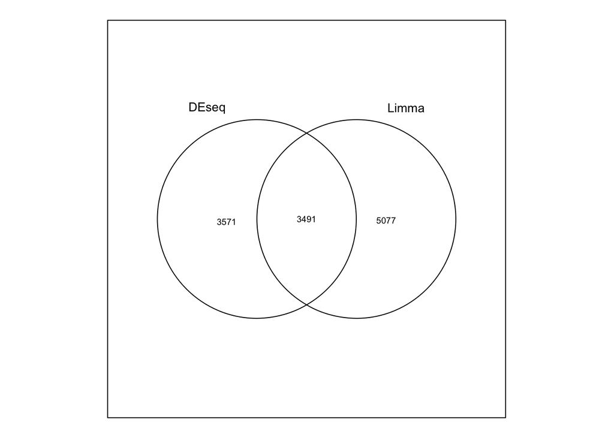

```r
df = merge(res_limma, as.data.frame(res), by=0, all=T)
# ggplot(df, aes(x = -log10(adj.P.Val), y = -log10(padj))) + geom_point(alpha=0.5)
rownames(res_limma) = res_limma$ensembl
ll = list(DEseq = rownames(res[which(res$padj<0.15),]),
     Limma = rownames(res_limma[which(res_limma$adj.P.Val<0.15),]))
venn(ll)
```

### FDR 10%

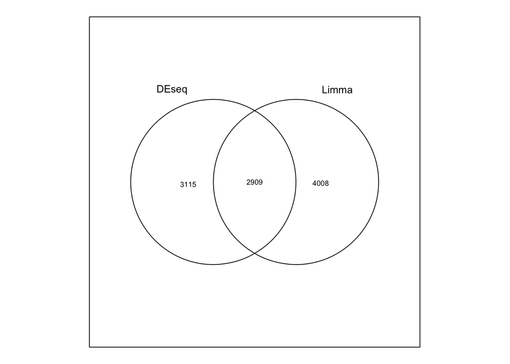

```r
df = merge(res_limma, as.data.frame(res), by=0, all=T)
# ggplot(df, aes(x = -log10(adj.P.Val), y = -log10(padj))) + geom_point(alpha=0.5)
ll = list(DEseq = rownames(res[which(res$padj<0.10),]),
     Limma = rownames(res_limma[which(res_limma$adj.P.Val<0.10),]))
venn(ll)
```

### FDR 5%

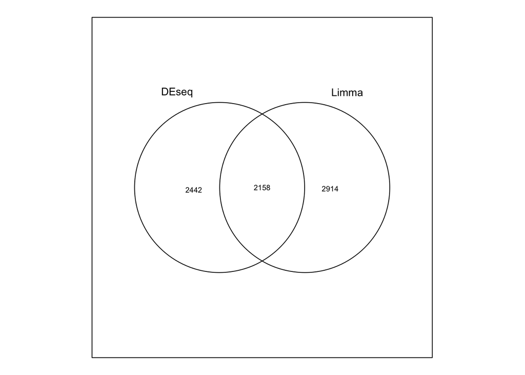

```r
df = merge(res_limma, as.data.frame(res), by=0, all=T)
# ggplot(df, aes(x = -log10(adj.P.Val), y = -log10(padj))) + geom_point(alpha=0.5)
ll = list(DEseq = rownames(res[which(res$padj<0.05),]),
     Limma = rownames(res_limma[which(res_limma$adj.P.Val<0.05),]))
venn(ll)
```

# Plots DESeq

### FDR distibution

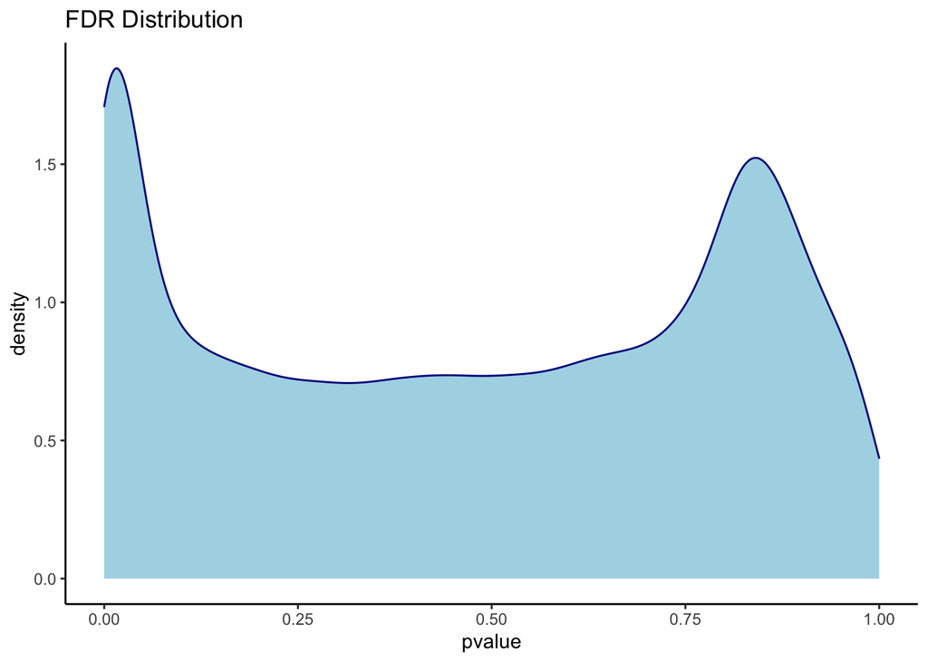

```r
res <- as.data.frame(res)
res = res
p = ggplot(res, aes(pvalue))
p + geom_density(color="darkblue", fill="lightblue") +
theme_classic() +
ggtitle("FDR Distribution")
```

### Fold change distribution

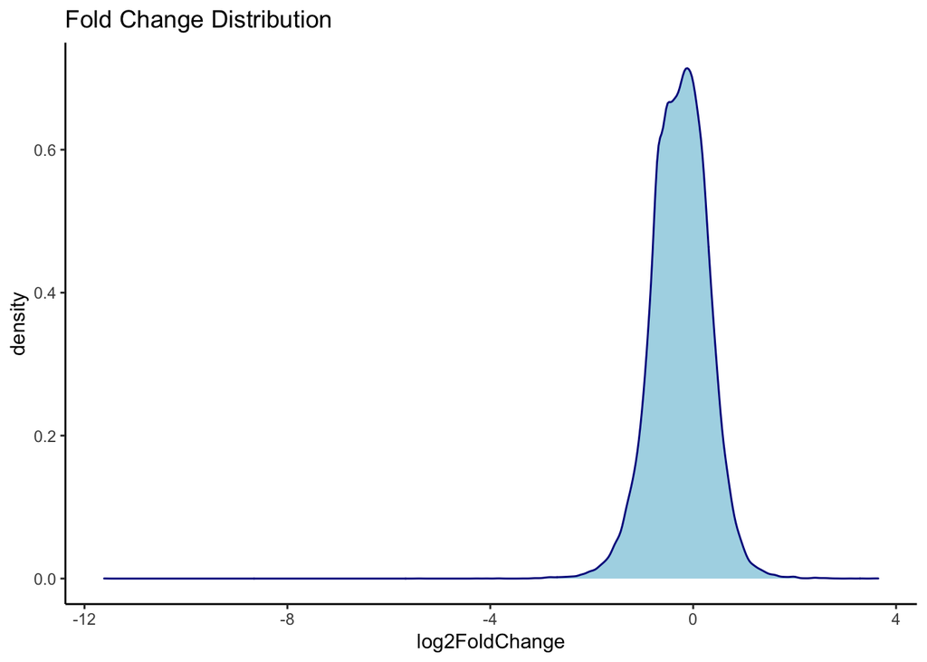

```r
p = ggplot(res, aes(log2FoldChange))
p + geom_density(color = "darkblue", fill = "lightblue") +
theme_classic() +
ggtitle("Fold Change Distribution")
```

### MA plot

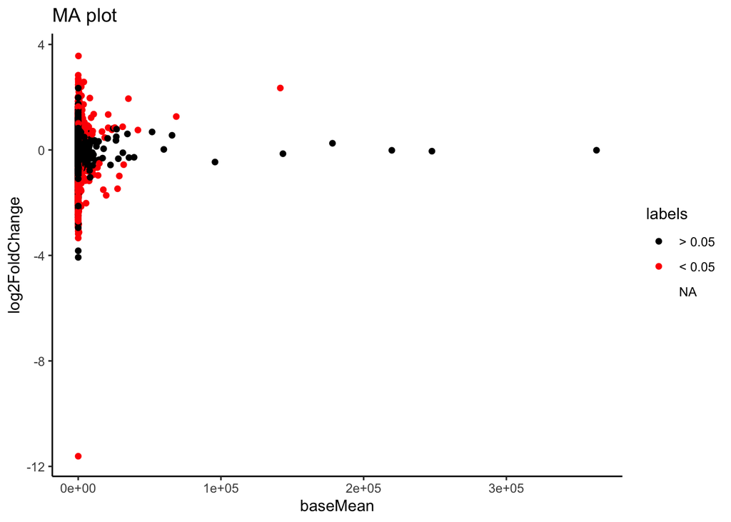

```r
plot.data = res
plot.data$id = rownames(plot.data)
data = data.frame(plot.data)
data$pvalue = -log10(data$pvalue)
data$fifteen = as.factor(abs(data$padj < 0.05))
ma = ggplot(data, aes(baseMean, log2FoldChange, color = fifteen))
ma + geom_point() +
scale_color_manual(values = c("black", "red"), labels = c ("> 0.05", "< 0.05")) +
labs(title = "MA plot", color = "labels") +
theme_classic()
```

### Volcano plot

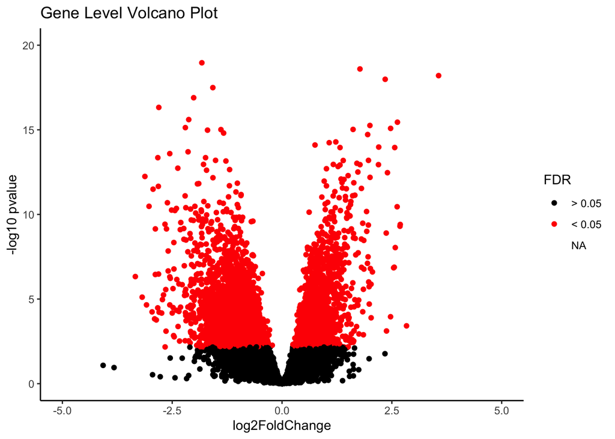

```r
vp = ggplot(data, aes(log2FoldChange, pvalue, color = fifteen))
vp + geom_point() +
scale_color_manual(values = c("black", "red"), labels = c("> 0.05", "< 0.05")) +
labs(title = "Gene Level Volcano Plot", color = "FDR") +
#theme(plot.title = element_text(hjust = 0.5)) +
theme_classic() +
xlim(-5,5) + ylim(0, 20) + ylab("-log10 pvalue")
```

### Direction of effect

#Direction of effect for SVZ compared to GFM is given, so logFC > 1 (these genes go up in SVZ, logFC < -1; these genes go down in SVZ)

```r
load("~/Documents/MiGASti/Databases/gene_matrix.RData")
metadata <- read.table("~/Documents/MiGASti/Databases/metadata2.txt", quote="\"", comment.char="")
#set rownames to Sample
row.names(metadata) <- metadata$Sample
#exclude samples that did not pass QC
exclude <- read.csv("~/Documents/MiGASti/Databases/samples2remove2.txt", sep="")
exclude <- exclude$x
genes_tpm_filt = genes_tpm[, !colnames(genes_tpm) %in% exclude]
#Excludes the samples from filters.
#dim(genes_tpm_filt)
metadata_filt = metadata[ !(rownames(metadata) %in% exclude), ]
length(metadata_filt)
```

[1] 38

```r
genes_tpm_filt = log2((genes_tpm_filt) + 1)
genes_tpm_filt <- as.data.frame(genes_tpm_filt)
genes_tpm_ordered <- genes_tpm_filt[,rownames(metadata_filt)]
#head(genes_tpm_ordered)
all(rownames(metadata_filt) == colnames (genes_tpm_ordered)) #TRUE
```

[1] TRUE

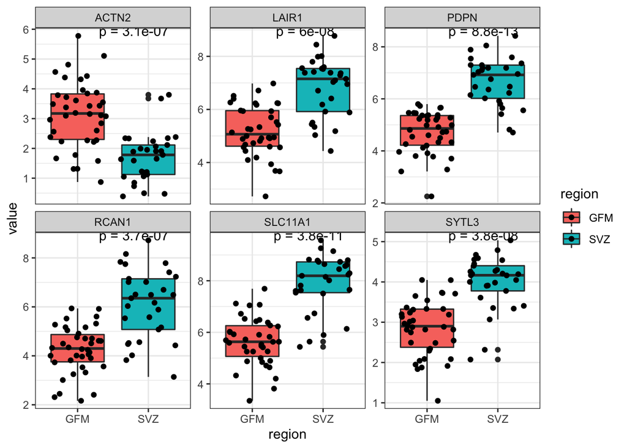

```r
load("~/Documents/MiGASti/Databases/res_DESEQ_SVZvsGFM.Rdata")
res_D <- as.data.frame(res)
gencode_30 = read.table("~/Documents/MiGASti/Databases/ens.geneid.gencode.v30")
res_2 <- tibble::rownames_to_column(res_D, "ensembl")
colnames(gencode_30) = c("ensembl","symbol")
res3 <- merge(res_2, gencode_30, by = "ensembl")

metadata_filt <- metadata_filt[metadata_filt$Stimulation == "unstim",]

samples_baseline = metadata_filt$Sample[metadata_filt$Region %in% "GFM"] # Includes same donor
samples_condition = metadata_filt$Sample[metadata_filt$Region %in% "SVZ"] # Includes same donor

metadata4deg = metadata_filt[rownames(metadata_filt) %in% c(samples_baseline,samples_condition) ,]

genes_voom_baseline_condition = as.data.frame(genes_tpm_ordered[, colnames(genes_tpm_ordered) %in% c(samples_baseline, samples_condition)])
# dim(genes_voom_baseline_condition)
# dim(metadata4deg)


deg_lists = res3[order(res$padj) ,]
top_6 = head(deg_lists)
top_6 <- as.data.frame(top_6)
gene2check = as.data.frame(genes_voom_baseline_condition[top_6$ensembl, ])

gene2check$ensembl = rownames(gene2check)
gene2check = merge(gene2check, top_6[, c("ensembl", "symbol")], by = "ensembl")

names(metadata4deg) = tolower(names(metadata4deg))

gene2check_m = melt(gene2check, id.vars = c("ensembl", "symbol"))
gene2check_charac = merge(gene2check_m, metadata4deg, by.x = "variable", by.y = "sample")

ggplot(gene2check_charac, aes(x = region, y = value, fill = region)) +
  geom_boxplot(notch = F, na.rm = T) +
  geom_jitter() +
  theme_bw() + facet_wrap(~symbol, scales = "free_y") +
  ggpubr::stat_compare_means(label = "p.format", label.x.npc = "centre", method = "wilcox.test")
```

# gprofiler

### DESeq SVZ x GFM up (logFC > 1)

```r
set3 <- subset(res3, padj< 0.05)
set3 <- subset(set3, log2FoldChange > 1)
set3_v <- set3$symbol
genes1 <- set3_v
library(gProfileR)

genes1 <- set3_v #SVZ up
go_res <- gprofiler(genes1, organism = "hsapiens", hier_filtering= "strong", min_set_size=5,  src_filter="GO" )
go_res %>% select(term.name, p.value, term.size, overlap.size)  %>% as_tibble() %>% arrange(p.value)
```

| term.name | p.value | term.size | overlap.size |
| --- | --- | --- | --- |
| immune response | 2.80e-21 | 2165 | 104 |
| vesicle | 3.51e-21 | 3788 | 143 |
| positive regulation of catalytic activity | 2.61e-06 | 1379 | 55 |
| actin cytoskeleton reorganization | 9.52e-05 | 92 | 12 |
| decidualization | 1.52e-04 | 23 | 7 |
| cell junction | 3.21e-04 | 1253 | 47 |
| cell death | 6.32e-04 | 2197 | 68 |
| molecular function regulator | 1.24e-03 | 1830 | 59 |
| protein-containing complex binding | 1.46e-03 | 996 | 39 |
| extracellular matrix organization | 1.92e-03 | 332 | 20 |

[output cut: 14 more lines]

```r
go_res
```

| query.number | significant | p.value | term.size | query.size | overlap.size | precision | recall | term.id | domain | subgraph.number | term.name | relative.depth | intersection |
| --- | --- | --- | --- | --- | --- | --- | --- | --- | --- | --- | --- | --- | --- |
| 1 | TRUE | 6.32e-04 | 2197 | 324 | 68 | 0.210 | 0.031 | GO:0008219 | BP | 9 | cell death | 1 | PTGS2,EDN1,EPB41L3,MAP3K4,LGALS1,TSPO,MMP9,HCK,TIMP1,HTR2A,CORO1A,CTSH,JAK3,MAG,FKBP8,CSF3,MFSD10,PTPN6,PPARD,STEAP3,ITGA4,PTPA,NCKAP1L,PDE1B,IL1B,RIPK3,ARHGEF6,ACTN4,IDO1,TRAF7,MYBBP1A,CHI3L1,IL2RA,I… |
| 1 | TRUE | 1.52e-04 | 23 | 324 | 7 | 0.022 | 0.304 | GO:0046697 | BP | 2 | decidualization | 1 | PTGS2,CYP27B1,PPARD,SPP1,STC1,CTSB,GJB2 |
| 1 | TRUE | 3.10e-03 | 84 | 324 | 10 | 0.031 | 0.119 | GO:0002456 | BP | 8 | T cell mediated immunity | 1 | WAS,SLC11A1,CTSH,IL23A,IL18R1,SASH3,IL1B,RIPK3,IL6,MYO1G |
| 1 | TRUE | 9.52e-05 | 92 | 324 | 12 | 0.037 | 0.130 | GO:0031532 | BP | 7 | actin cytoskeleton reorganization | 1 | HCK,CSF3,TRPV4,GPR65,MINK1,TRPM2,F11R,S100A9,CDK5,CSF1R,FLNA,SIPA1L1 |
| 1 | TRUE | 4.66e-03 | 206 | 324 | 15 | 0.046 | 0.073 | GO:0034329 | BP | 22 | cell junction assembly | 1 | CD9,EPB41L3,SH3BP1,TRPV4,ACTN4,IQGAP1,RAB13,MMP14,F11R,GJB2,CD151,LAMB3,FLNA,S100A10,MYO1C |
| 1 | TRUE | 1.92e-03 | 332 | 324 | 20 | 0.062 | 0.060 | GO:0030198 | BP | 15 | extracellular matrix organization | 1 | ITGAL,MMP9,TIMP1,ITGB8,PLOD3,ENG,SPARC,ITGA4,MMP8,SPP1,TGFBI,MMP3,MMP14,F11R,ITGB2,PDPN,LAMB2,MMP1,LAMB3,DDR1 |
| 1 | TRUE | 3.34e-02 | 133 | 324 | 11 | 0.034 | 0.083 | GO:0038094 | BP | 24 | Fc-gamma receptor signaling pathway | 1 | WAS,HCK,FCGRT,NCKAP1L,PLD2,MYO1G,DOCK1,FCER1G,MYO1C,PLPP4,CYFIP1 |
| 1 | TRUE | 2.61e-06 | 1379 | 324 | 55 | 0.170 | 0.040 | GO:0043085 | BP | 5 | positive regulation of catalytic activity | 1 | SLC11A1,EDN1,MAP3K4,TBC1D2,SH3BP1,SGSM3,HTR2A,CCL22,CSK,CTSH,CEMIP,SYDE1,CD81,IL23A,CYP27B1,MAPKAPK3,CCL20,PTPA,ARHGAP9,NCKAP1L,EREG,IL1B,RIPK3,ARHGEF6,TBC1D5,TRAF7,CHI3L1,DOCK2,CIDEB,GPR65,IQGAP1,MIN… |
| 1 | TRUE | 2.80e-21 | 2165 | 324 | 104 | 0.321 | 0.048 | GO:0006955 | BP | 1 | immune response | 1 | ITGAL,ALDH3B1,WAS,SLC11A1,MARCO,SERPINB1,TNIP3,KCNAB2,CST7,EDN1,UNC13D,TREM2,LGALS1,MMP9,HCK,CORO1A,CCL22,CSK,CTSH,ATP8B4,MAN2B1,FCGRT,SIGLEC5,JAK3,CSF3,CD81,IL23A,CYP27B1,PTPN6,PDE4D,MAPKAPK3,CCL20,I… |
| 1 | TRUE | 3.20e-02 | 469 | 324 | 22 | 0.068 | 0.047 | GO:0070838 | BP | 16 | divalent metal ion transport | 1 | SLC11A1,PTGS2,TSPO,HTR2A,CORO1A,CEMIP,CYP27B1,TRPV4,PTPN6,SLC39A7,PDE4D,ARRB2,TRPM2,SLC39A1,SNCA,CACNA2D4,MCOLN2,CACNA2D3,STC1,CDK5,P2RY6,ANXA6 |

[output cut: 14 more lines]

### DESeq SVZ x GFM down (logFC < -1)

```r
set3 <- subset(res3, padj < 0.05)
set3 <- subset(set3, log2FoldChange < -1)
set3_v <- set3$symbol
genes1 <- set3_v
library(gProfileR)

genes1 <- set3_v #SVZ down
go_res <- gprofiler(genes1, organism = "hsapiens", hier_filtering= "strong", min_set_size=5,  src_filter="GO" )
go_res %>% select(term.name, p.value, term.size, overlap.size)  %>% as_tibble() %>% arrange(p.value)
```

| term.name | p.value | term.size | overlap.size |
| --- | --- | --- | --- |
| response to stimulus | 1.77e-15 | 9017 | 453 |
| protein dimerization activity | 1.08e-07 | 1300 | 97 |
| locomotion | 4.58e-06 | 1842 | 119 |
| nucleosome | 8.73e-06 | 108 | 20 |
| cell-cell adhesion | 4.21e-05 | 776 | 62 |
| extracellular region | 5.45e-05 | 4453 | 230 |
| regulation of transcription regulatory region DNA binding | 5.74e-05 | 49 | 13 |
| anchored component of plasma membrane | 5.35e-04 | 49 | 12 |
| secretion by cell | 1.34e-03 | 1439 | 91 |
| chromatin assembly | 2.13e-03 | 162 | 21 |

[output cut: 11 more lines]

```r
go_res
```

| query.number | significant | p.value | term.size | query.size | overlap.size | precision | recall | term.id | domain | subgraph.number | term.name | relative.depth | intersection |
| --- | --- | --- | --- | --- | --- | --- | --- | --- | --- | --- | --- | --- | --- |
| 1 | TRUE | 1.77e-15 | 9017 | 727 | 453 | 0.623 | 0.050 | GO:0050896 | BP | 1 | response to stimulus | 1 | CASP10,PDK4,CALCR,MPO,SOX8,TAC1,TNFRSF12A,SELE,PLEKHG6,PGLYRP1,IL32,PRSS3,LTF,GPRC5A,IGF1,SNAI2,EHD2,ADRB1,ARAP2,LTBP1,BCAR1,OPN3,FOXC1,CYFIP2,DCBLD2,CAMK2B,GPC1,TSPAN32,COL17A1,LIMS2,TBX21,NTN4,TACR2… |
| 1 | TRUE | 1.34e-03 | 1439 | 727 | 91 | 0.125 | 0.063 | GO:0032940 | BP | 4 | secretion by cell | 1 | MPO,TAC1,PGLYRP1,PRSS3,LTF,IGF1,TACR2,ACTN2,FGF20,FCN1,RAPGEF4,CRISP3,PCSK5,TIMP3,CTSG,BPI,OLFM4,FOXF1,RETN,FOLR3,IL1R2,IL1RL1,CD2,ZP4,GBP1,LRMP,ARG1,CCR2,TWIST1,CEACAM8,F13A1,SOX4,FOXA2,LIF,KCNA5,SNA… |
| 1 | TRUE | 9.05e-03 | 85 | 727 | 14 | 0.019 | 0.165 | GO:0001523 | BP | 8 | retinoid metabolic process | 1 | GPC1,DHRS9,GPC4,CYP26A1,RDH10,LRAT,OPN1SW,RBP4,CYP1A1,CRABP2,GPC3,AKR1C1,AKR1C3,BCO2 |
| 1 | TRUE | 7.16e-03 | 448 | 727 | 38 | 0.052 | 0.085 | GO:0042110 | BP | 16 | T cell activation | 1 | IGF1,TBX21,BMX,HES1,CD2,ZP4,ARG1,EGR1,CCR2,SOX4,IRF1,TNFSF9,RSAD2,XCL1,CDKN2A,IL18,CD8A,CXADR,TNFRSF13C,JAML,F2RL1,CD3D,TMIGD2,IL12A,PTGER4,IFNB1,CD8B,FZD8,EGR3,LCK,IFNE,SOCS1,HSH2D,IL27,NRARP,KLRK1,H… |
| 1 | TRUE | 2.24e-02 | 21 | 727 | 7 | 0.010 | 0.333 | GO:0035743 | BP | 14 | CD4-positive, alpha-beta T cell cytokine production | 1 | TBX21,ARG1,RSAD2,XCL1,IL18,IL12A,IFNB1 |
| 1 | TRUE | 4.79e-02 | 10 | 727 | 5 | 0.007 | 0.500 | GO:2000551 | BP | 17 | regulation of T-helper 2 cell cytokine production | 1 | TBX21,ARG1,RSAD2,XCL1,IFNB1 |
| 1 | TRUE | 2.13e-03 | 162 | 727 | 21 | 0.029 | 0.130 | GO:0031497 | BP | 11 | chromatin assembly | 1 | CENPM,HJURP,HIST1H2BJ,SOX9,CDKN2A,PADI4,CENPV,HIST1H2BL,HIST3H2BB,HIST2H3C,HIST2H2BF,HIST2H3A,HIST1H2BG,HIST1H2BO,HIST1H3I,HIST1H2BH,HIST1H3A,HIST1H2BB,HIST1H2BF,HIST1H3C,HIST1H3H |
| 1 | TRUE | 4.21e-05 | 776 | 727 | 62 | 0.085 | 0.080 | GO:0098609 | BP | 19 | cell-cell adhesion | 1 | SELE,IGF1,SNAI2,CYFIP2,TSPAN32,LIMS2,TBX21,IGSF9B,JAG1,FOXF1,ICAM5,HES1,CD2,ZP4,ARG1,EPCAM,CCR2,CEACAM8,IRF1,SOX9,TNFSF9,FOXA2,BMP2,PODXL,GATA5,SERPINE2,PCDH8,KLF4,CDH24,XCL1,CDKN2A,ESAM,IL18,CXADR,TN… |
| 1 | TRUE | 4.58e-06 | 1842 | 727 | 119 | 0.164 | 0.065 | GO:0040011 | BP | 2 | locomotion | 1 | SOX8,TAC1,TNFRSF12A,SELE,PRSS3,IGF1,SNAI2,BCAR1,FOXC1,GPC1,NAV3,TBX21,NTN4,TACR2,TNS1,BAMBI,JAG1,FAM83D,NDRG4,FOXF1,CCL24,LHX2,SLC9A3R1,MDK,WNT5B,HES1,CD2,SGK1,PGF,EPCAM,TEK,CCR2,TWIST1,SNAI1,CEACAM8,… |
| 1 | TRUE | 5.74e-05 | 49 | 727 | 13 | 0.018 | 0.265 | GO:2000677 | BP | 6 | regulation of transcription regulatory region DNA binding | 1 | IGF1,FOXC1,LHX2,HAND1,TWIST1,ID1,LIF,HEY2,KLF4,MSX1,HEY1,ENHO,ZBTB7C |

[output cut: 11 more lines]

# Comparison plots

### Venn diagram showing overlap of differentially expressed genes SVZ x GFM in vitro + SVZ LPS

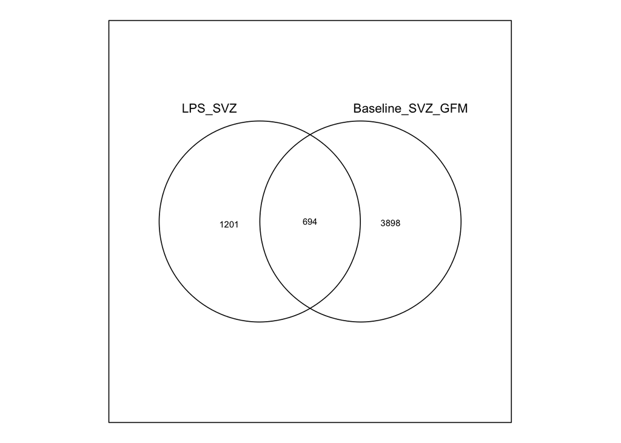

```r
DEG_LPS_SVZ <- read.table("DEG_LPS_SVZ.txt")
DEG_LPS_SVZ <- DEG_LPS_SVZ[!duplicated(DEG_LPS_SVZ$symbol), ]
res3 <- res3[!duplicated(res3$symbol), ]
rownames(DEG_LPS_SVZ) = DEG_LPS_SVZ$symbol
rownames(res3) = res3$symbol
df = merge(DEG_LPS_SVZ, as.data.frame(res3), by=0, all=T)
# ggplot(df, aes(x = -log10(adj.P.Val), y = -log10(padj))) + geom_point(alpha=0.5)
ll = list(LPS_SVZ = rownames(DEG_LPS_SVZ[which(DEG_LPS_SVZ$padj<0.05),]),
     Baseline_SVZ_GFM = rownames(res3[which(res3$padj<0.05),]))
venn(ll)
```

### Venn diagram showing overlap of differentially expressed genes SVZ x GFM in vitro + SVZ IFNy

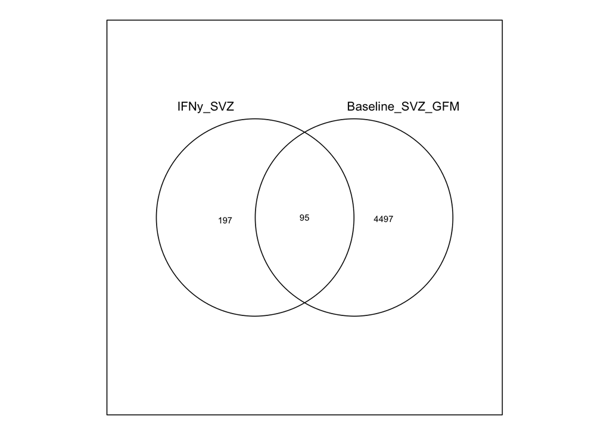

```r
DEG_LPS_SVZ <- read.table("DEG_IFNy_SVZ.txt")
load("~/Documents/MiGASti/Databases/res_DESEQ_SVZvsGFM.Rdata")
res_D <- as.data.frame(res)
gencode_30 = read.table("~/Documents/MiGASti/Databases/ens.geneid.gencode.v30")
res_2 <- tibble::rownames_to_column(res_D, "ensembl")
colnames(gencode_30) = c("ensembl","symbol")
res3 <- merge(res_2, gencode_30, by = "ensembl")
DEG_LPS_SVZ <- DEG_LPS_SVZ[!duplicated(DEG_LPS_SVZ$symbol), ]
res3 <- res3[!duplicated(res3$symbol), ]
rownames(DEG_LPS_SVZ) = DEG_LPS_SVZ$symbol
rownames(res3) = res3$symbol
df = merge(DEG_LPS_SVZ, as.data.frame(res3), by=0, all=T)
# ggplot(df, aes(x = -log10(adj.P.Val), y = -log10(padj))) + geom_point(alpha=0.5)
rownames(DEG_LPS_SVZ) = DEG_LPS_SVZ$symbol
rownames(res3) = res3$symbol
ll = list(IFNy_SVZ = rownames(DEG_LPS_SVZ[which(DEG_LPS_SVZ$padj<0.05),]),
     Baseline_SVZ_GFM = rownames(res3[which(res3$padj<0.05),]))
venn(ll)
```

### Plot showing differential expressed genes in SVZ after LPS stimulation compared to genes that are differentially expressed in vitro in SVZ to GFM

#1.Genes that overlap between datasets #2.Genes that overlap with Patir

```r
load("~/Documents/MiGASti/Databases/res_DESEQ_SVZvsGFM.Rdata")
res_D <- as.data.frame(res)
gencode_30 = read.table("~/Documents/MiGASti/Databases/ens.geneid.gencode.v30")
res_2 <- tibble::rownames_to_column(res_D, "ensembl")
colnames(gencode_30) = c("ensembl","symbol")
res3 <- merge(res_2, gencode_30, by = "ensembl")
DEG_LPS_SVZ <- read.table("DEG_LPS_SVZ.txt")
DEG_LPS_SVZ <- subset(DEG_LPS_SVZ, padj < 0.05)
DEG_baseline_SVZ <- subset(res3, padj < 0.05)

overlap <- merge(DEG_LPS_SVZ, DEG_baseline_SVZ, by = "symbol")
unique(overlap$symbol)
```

[1] “AAAS” “ABAT” “ABCA13” “ABCD3” “ABHD16A”  
[6] “ABHD2” “ABHD4” “ABI3” “ABR” “ABTB2”  
[11] “AC004130.1” “AC005899.8” “AC007384.1” “AC007613.1” “AC007950.1” [16] “AC008691.1” “AC011511.5” “AC011939.1” “AC012020.1” “AC012368.1” [21] “AC016831.1” “AC016831.7” “AC022509.1” “AC025164.1” “AC061992.1” [26] “AC068580.4” “AC069209.1” “AC079753.1” “AC090114.2” “AC090197.1” [31] “AC090236.2” “AC092327.2” “AC099343.3” “AC114977.2” “AC133552.1” [36] “ACADSB” “ACBD3” “ACER3” “ACKR3” “ACSL1”  
[41] “ACTR3B” “ACVR1” “ADAM28” “ADAMTS4” “ADARB1”  
[46] “ADGRE1” “ADH5” “ADIRF” “AF117829.1” “AF127577.4” [51] “AGL” “AGMAT” “AK4” “AL021155.2” “AL024508.1” [56] “AL122018.1” “AL137186.2” “AL158050.1” “AL158064.1” “AL162377.1” [61] “AL353708.1” “AL357060.1” “AL358473.1” “AL390961.3” “ALCAM”  
[66] “ALDH2” “ALDH3B1” “ALG1” “ALOX5AP” “ANGPTL4”  
[71] “ANKLE2” “ANKRD22” “ANKRD39” “ANKRD54” “ANKRD9”  
[76] “ANO10” “ANXA3” “AP002387.2” “AP2S1” “APBB3”  
[81] “APCDD1” “APMAP” “ARAP2” “ARC” “AREG”  
[86] “ARG2” “ARHGAP10” “ARHGAP18” “ARHGAP24” “ARHGAP9”  
[91] “ARL4C” “ARMC10” “ARMH4” “ASAH1” “ATP2B1-AS1” [96] “ATP6AP2” “ATP6V1C1” “AZIN2” “B3GALNT1” “B3GAT3”  
[101] “B3GNT7” “BAZ1A” “BBS9” “BCAP31” “BCL2”  
[106] “BEND3P3” “BLOC1S4” “BNC2” “BRAF” “BRCA2”  
[111] “BRCC3” “BSCL2” “BSG” “C12orf50” “C12orf75”  
[116] “C16orf87” “C19orf38” “C1GALT1C1” “C1orf162” “C1orf56”  
[121] “C1orf61” “C3orf52” “C5AR1” “C5orf56” “C9orf135”  
[126] “CALHM2” “CAMK2A” “CAMK2D” “CAMKK2” “CAMSAP2”  
[131] “CAPN1” “CASP4” “CASP5” “CCDC134” “CCDC149”  
[136] “CCDC22” “CCDC50” “CCPG1” “CCR2” “CCT6P1”  
[141] “CD14” “CD300A” “CD44” “CD46” “CD48”  
[146] “CD80” “CD9” “CDCP1” “CDK5” “CDKL1”  
[151] “CDKN2B” “CDKN2B-AS1” “CEP135” “CHAC1” “CHI3L2”  
[156] “CHID1” “CHML” “CHST15” “CHST7” “CIDEB”  
[161] “CKB” “CLEC17A” “CLIC4” “CLIC5” “CMKLR1”  
[166] “CMPK2” “CNPY3” “COMMD3” “CORO1A” “CORO1B”  
[171] “CORO1C” “CPAMD8” “CPEB3” “CPM” “CPNE3”  
[176] “CPVL” “CRLS1” “CRNDE” “CSF3” “CSK”  
[181] “CSKMT” “CSRP1” “CSRP2” “CTNNBL1” “CTSA”  
[186] “CTSB” “CTSD” “CTSH” “CTSL” “CXADR”  
[191] “CXCL1” “CXCL16” “CXCL3” “CXXC1” “CYB5R3”  
[196] “CYFIP1” “CYP27B1” “DBF4” “DCBLD1” “DDAH2”  
[201] “DDX41” “DENND1C” “DENND5A” “DERA” “DHCR24”  
[206] “DHCR7” “DHRS7” “DICER1” “DISP1” “DLGAP1-AS2” [211] “DNAJC3” “DOCK2” “DOCK7” “DOK1” “DONSON”  
[216] “DRGX” “DUSP1” “DUSP2” “E2F7” “EDN1”  
[221] “EGR1” “EGR2” “EGR4” “EHD1” “ENO2”  
[226] “ENOSF1” “ENPP2” “ENTPD1” “EREG” “ERLEC1”  
[231] “ESYT1” “EVA1C” “EXT1” “EYA4” “F3”  
[236] “FADS2” “FAM117B” “FAM241A” “FAM89A” “FCAMR”  
[241] “FDX1” “FGF13” “FIG4” “FLYWCH2” “FNDC3A”  
[246] “FPR2” “FZD4” “GALK1” “GALNT6” “GAPDH”  
[251] “GBA” “GBP1” “GBP2” “GBP3” “GBP4”  
[256] “GBP5” “GCNT4” “GGTA1P” “GJB2” “GJC1”  
[261] “GLB1” “GLIPR2” “GLMP” “GMEB2” “GMPPB”  
[266] “GNA12” “GNB4” “GNG4” “GNPTAB” “GPNMB”  
[271] “GPR65” “GPR84” “GPRC5B” “GPRIN3” “GPS1”  
[276] “GPX1” “GRAMD1A” “GRAMD2B” “GRK2” “GRN”  
[281] “GSPT1” “GTF2IRD2B” “HACD3” “HADHB” “HAPLN3”  
[286] “HAUS4” “HCAR3” “HCK” “HCLS1” “HDAC1”  
[291] “HECTD2” “HERC5” “HES1” “HEY1” “HINT3”  
[296] “HIST1H2AE” “HIST1H2BB” “HIST1H2BG” “HIST1H2BJ” “HLA-L”  
[301] “HMOX1” “HPF1” “HPS1” “HPSE” “HS3ST3B1”  
[306] “HS3ST4” “HSD17B11” “HSD3B7” “HYAL3” “HYDIN”  
[311] “IBA57” “IDO1” “IDS” “IER5” “IFI44L”  
[316] “IFIH1” “IFIT1” “IFIT2” “IFIT3” “IFNB1”  
[321] “IFNGR2” “IGFBP4” “IGFLR1” “IKBKE” “IL15RA”  
[326] “IL1B” “IL23A” “IL2RA” “IL6” “ING5”  
[331] “INHBA-AS1” “INPP5D” “INTS6-AS1” “IRF3” “ISG15”  
[336] “ITGA2” “ITGA9” “ITGAL” “ITGAM” “ITGB2”  
[341] “ITGB8” “JKAMP” “KANK1” “KANK2” “KAT2B”  
[346] “KCNAB2” “KCNJ2” “KCNMA1” “KCTD3” “KDSR”  
[351] “KHDRBS1” “KIAA0930” “KIF9-AS1” “KL” “KLF5”  
[356] “KLHL21” “KLHL24” “KRT17P1” “LAD1” “LAMA2”  
[361] “LAMA3” “LAMP3” “LAPTM5” “LAT2” “LDHD”  
[366] “LEPROTL1” “LILRA2” “LILRB1” “LILRB3” “LIMK2”  
[371] “LINC00309” “LINC00702” “LINC02381” “LIPA” “LONRF1”  
[376] “LPCAT2” “LPCAT3” “LRIG1” “LRMDA” “LRP1”  
[381] “LRP11” “LRP12” “LRRC8A” “LRRFIP2” “LSS”  
[386] “LTA4H” “LXN” “MAD1L1” “MAD2L2” “MAFF”  
[391] “MAGED2” “MAN1B1” “MAN1B1-DT” “MANEA” “MAP3K7CL”  
[396] “MAP3K8” “MAP4K5” “MAPK10” “MAPK13” “MAPKAPK3”  
[401] “MARCKS” “MAZ” “MCMBP” “MCOLN2” “MED12L”  
[406] “MEGF11” “MFNG” “MFSD1” “MIR3142HG” “MITF”  
[411] “MKNK1” “MLYCD” “MMP10” “MMP3” “MMP9”  
[416] “MORC4” “MPP1” “MREG” “MS4A14” “MSTO1”  
[421] “MTUS1” “MX2” “MYC” “MYO1B” “MYO1F”  
[426] “MYO1G” “N4BP2L1” “NAMPT” “NAV3” “NCAPG2”  
[431] “NCEH1” “NCKAP1L” “NCMAP” “NDRG3” “NECTIN2”  
[436] “NEDD4” “NEDD4L” “NEK7” “NFE2L3” “NFIA”  
[441] “NFKBIA” “NFKBIZ” “NIPAL4” “NISCH” “NKX3-1”  
[446] “NMRAL1” “NOCT” “NOL4L” “NPL” “NPTN”  
[451] “NRDC” “NRIP1” “NRM” “NUDT4” “NUDT5”  
[456] “OASL” “OPN3” “OTUD4” “OTULIN” “P3H2”  
[461] “PAPSS1” “PAPSS2” “PAQR7” “PAQR8” “PARP12”  
[466] “PARVG” “PAXIP1-AS1” “PBX3” “PCDH9” “PCED1A”  
[471] “PCGF5” “PDE2A” “PDGFA” “PDGFC” “PDP1”  
[476] “PDSS1” “PELI1” “PEX19” “PGAP3” “PGM2”  
[481] “PI3” “PIK3R6” “PIM2” “PIP4P2” “PLA2G15”  
[486] “PLAC8” “PLCE1” “PLCL2” “PLCXD2” “PLEKHH1”  
[491] “PLIN5” “PLK3” “PLPBP” “PLXDC2” “PMAIP1”  
[496] “PNMA1” “PNPO” “PNRC1” “POMT1” “POT1”  
[501] “PPARG” “PPP4R4” “PPT1” “PRCP” “PRKAR1B”  
[506] “PRMT9” “PROCR” “PRPSAP2” “PSD3” “PSEN2”  
[511] “PSTPIP1” “PSTPIP2” “PTGIR” “PTGS1” “PTGS2”  
[516] “PTPN2” “PTPRE” “PXYLP1” “PYGL” “QARS”  
[521] “QPCTL” “RAB21” “RAB22A” “RAD17” “RAP1GDS1”  
[526] “RAPGEF1” “RASSF8” “RASSF8-AS1” “RCAN2” “RCBTB2”  
[531] “RCN1” “RDH11” “REST” “RGS1” “RGS14”  
[536] “RGS16” “RHOBTB3” “RIPK3” “RNASE1” “RND1”  
[541] “RNF115” “RNF217” “ROR1-AS1” “RPA1” “RRAD”  
[546] “RRAS2” “RSAD2” “RUBCNL” “RUFY3” “RXRA”  
[551] “SAMSN1” “SATB2” “SCCPDH” “SCD” “SCP2”  
[556] “SCPEP1” “SDC4” “SDSL” “SEC61A2” “SEMA4A”  
[561] “SERPINA1” “SERPINB1” “SERPINE2” “SFXN3” “SH2D4A”  
[566] “SHC3” “SIAH2” “SIGLEC9” “SIPA1L2” “SKAP2”  
[571] “SLA” “SLAMF1” “SLAMF8” “SLC16A3” “SLC17A5”  
[576] “SLC22A18AS” “SLC25A33” “SLC25A40” “SLC25A45” “SLC26A2”  
[581] “SLC29A1” “SLC2A6” “SLC35B4” “SLC36A1” “SLC39A8”  
[586] “SLC43A3” “SLC9A6” “SLCO2B1” “SLIT2” “SMAD3”  
[591] “SMAD4” “SMG7-AS1” “SNCA” “SNN” “SOCS1”  
[596] “SPARC” “SPRY2” “SPSB1” “SRC” “SRGAP3”  
[601] “SRXN1” “ST3GAL4” “ST3GAL6” “ST6GALNAC4” “ST8SIA4”  
[606] “STAB1” “STAT4” “STEAP1B” “STOM” “STON2”  
[611] “STX10” “STX12” “SUCLG2” “SVIL” “SYNPO2”  
[616] “TBC1D2” “TBC1D22A” “TBC1D5” “TBC1D9B” “TCTN3”  
[621] “TEX264” “TFDP2” “TGFA” “TGFBI” “THNSL2”  
[626] “THUMPD2” “TIAM2” “TIMP3” “TJP2” “TLE1”  
[631] “TMC6” “TMEM104” “TMEM106A” “TMEM106C” “TMEM109”  
[636] “TMEM14A” “TMEM14C” “TMEM206” “TMEM217” “TMEM248”  
[641] “TMEM256” “TMEM39A” “TMEM87B” “TNC” “TNF”  
[646] “TNFSF10” “TNFSF12” “TNFSF13” “TNFSF4” “TNIP1”  
[651] “TNIP3” “TP53BP2” “TPBG” “TPCN1” “TPD52L2”  
[656] “TRAF3IP3” “TREM2” “TRIB1” “TRIM22” “TSPAN4”  
[661] “TTC38” “TUBA1A” “TUBGCP2” “TWF2” “TYROBP”  
[666] “UBE2E2” “UBE2H” “UBE2Z” “UBL4A” “UBTD2”  
[671] “UBXN11” “UBXN2A” “ULK2” “UNC119” “UPB1”  
[676] “USP12” “USP6” “VAMP8” “VAV1” “VPS41”  
[681] “VPS45” “VPS8” “WAS” “WTAP” “XPO7”  
[686] “XRCC1” “YBX3” “Z93241.1” “ZC3H7A” “ZNF385C”  
[691] “ZNF57” “ZNF675” “ZNF687-AS1” “ZNF771”

```r
genes <- merge(overlap, Patir, by = "symbol")
list(genes$symbol)
```

[[1]] [1] “ABI3” “ADAM28” “ALOX5AP” “CD14” “CD300A” “CLEC17A” [7] “CMKLR1” “CXCL16” “CYFIP1” “DOCK2” “HCK” “HCLS1”  
[13] “INPP5D” “ITGAL” “ITGAM” “ITGB2” “LAPTM5” “LAT2”  
[19] “LILRB1” “MYO1F” “NCKAP1L” “PARVG” “PLXDC2” “RGS1”  
[25] “SAMSN1” “SERPINA1” “SIGLEC9” “STAB1” “TMEM106A” “TRAF3IP3” [31] “TREM2” “TRIM22” “TYROBP” “VAMP8” “VAV1” “WAS”

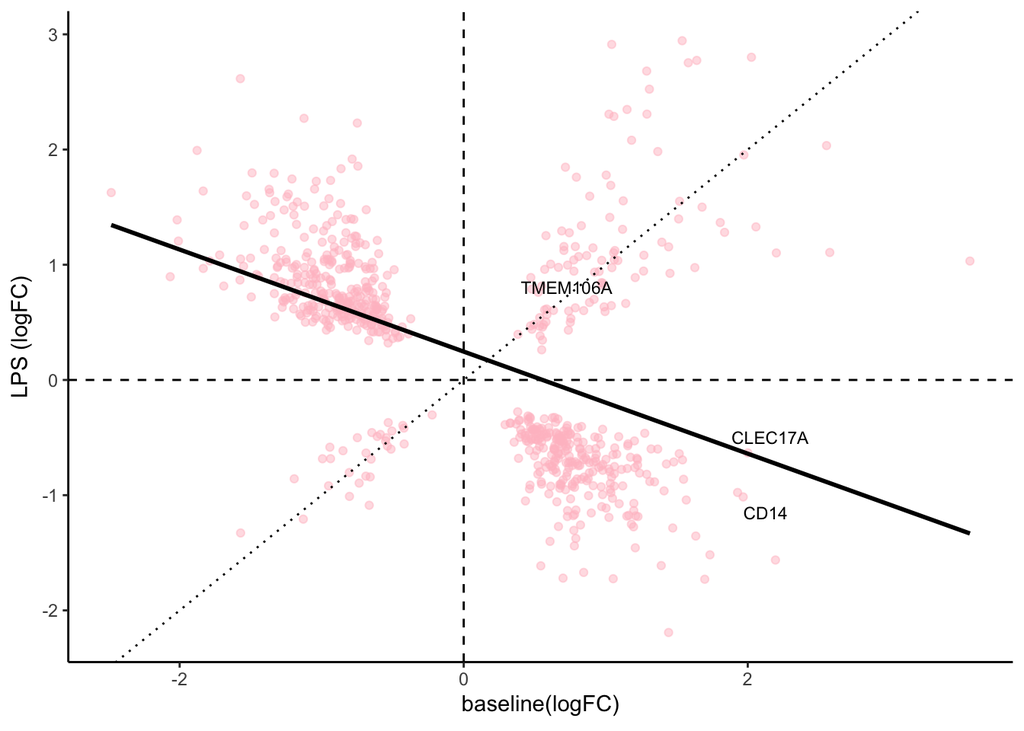

```r
LPS_SVZ <- overlap[,4]
baseline_SVZ <- overlap[,11]
df = data.frame(LPS_SVZ, baseline_SVZ)

rownames(df) = overlap$symbol

symbol4label = c("AB13", "ADAM28", "CD14", "CLEC17A", "TREM2", "TYROBP", "TMEM106A")
genes_m_filt4lab = df
genes_m_filt4lab$overlap = rownames(genes_m_filt4lab)
genes_m_filt4lab$overlap[(!genes_m_filt4lab$overlap %in% symbol4label)] = ""


p3 <-  ggplot(genes_m_filt4lab, aes(x = baseline_SVZ, y = LPS_SVZ)) +
  geom_point(alpha=.5, color="pink")+
  geom_hline(yintercept = 0, linetype = "dashed", colour = "black") +
  geom_vline(xintercept = 0, linetype = "dashed", colour = "black") +
  stat_smooth(method = "lm", se=F, color="black") + # Add Regression Line  +
  geom_abline(slope = 1, intercept = 0, linetype = 3)
p3 + geom_text_repel(aes(label = overlap),
                    size = 3) + easy_labs(x = expression(paste("baseline(", logFC,")")), y = expression(paste("LPS (", logFC, ")"))) +
  theme_classic()
```

### Plot showing differential expressed genes in SVZ after IFNy stimulation compared to genes that are differentially expressed in vitro in SVZ to GFM

#1. Genes that overlap between datasets #2. Genes that overlap with Patir

```r
DEG_LPS_SVZ <- read.table("DEG_IFNy_SVZ.txt")
DEG_LPS_SVZ <- subset(DEG_LPS_SVZ, padj < 0.05)
DEG_baseline_SVZ <- subset(res3, padj < 0.05)

overlap <- merge(DEG_LPS_SVZ, DEG_baseline_SVZ, by = "symbol")
list(overlap$symbol)
```

[[1]] [1] “ABCA17P” “AC005515.1” “AC006160.1” “AC007728.2” “AC011511.5” [6] “AC012020.1” “AC079630.1” “AC099343.3” “AC116366.1” “ACSM5”  
[11] “AL024508.1” “AL672207.1” “ANKRD22” “ANXA2R” “ANXA3”  
[16] “APOL4” “ARAP2” “BATF2” “BAZ1A” “BRCA2”  
[21] “C1QA” “C21orf91” “C4A” “C5orf56” “CASP10”  
[26] “CASP4” “CASP8” “CEACAM1” “CIITA” “CNDP2”  
[31] “CXCL9” “DAAM1” “DDHD1” “DDX23” “ETV7”  
[36] “FAM122C” “FANCF” “FGD2” “FYB1” “GBP1”  
[41] “GBP2” “GBP3” “GBP4” “GBP5” “GIMAP1”  
[46] “GJB2” “GLT8D1” “GSDMD” “GSTK1” “HAPLN3”  
[51] “HLA-DMB” “IDO1” “IFI44L” “IFIT3” “IFITM1”  
[56] “IGHEP2” “IL15RA” “IL32” “IRF1” “KCNJ2”  
[61] “KIAA0040” “LGALS3BP” “LINC00996” “MAP2” “MLKL”  
[66] “N4BP2L1” “NCOA7” “NEURL3” “NUB1” “PLEKHH1”  
[71] “PROCR” “PRR5L” “PRRG4” “PSMB9” “PSTPIP2”  
[76] “PTGS2” “RARRES3” “RNF114” “RSAD2” “SCO1”  
[81] “SERPING1” “SLAMF8” “SP110” “SSPN” “STAMBPL1”  
[86] “STOM” “SYNJ2BP” “TAPBP” “TNFSF10” “TRAFD1”  
[91] “TRIM22” “TRIM69” “USP15” “XIRP1” “ZNF583”

```r
genes <- merge(overlap, Patir, by = "symbol")
list(genes$symbol)
```

[[1]] [1] “C1QA” “CIITA” “FGD2” “FYB1” “HLA-DMB” “TRIM22”

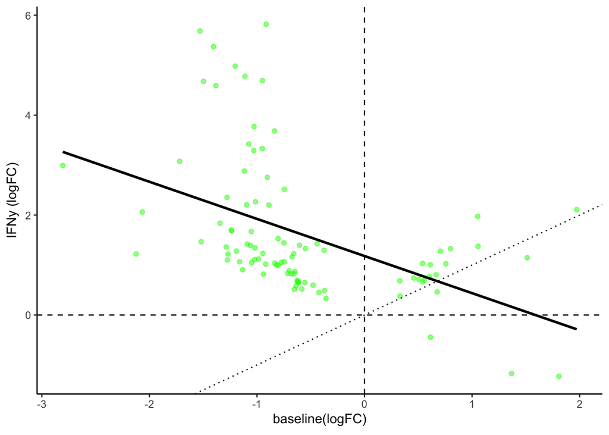

```r
LPS_SVZ <- overlap[,4]
baseline_SVZ <- overlap[,11]
df = data.frame(baseline_SVZ, LPS_SVZ)

rownames(df) = overlap$symbol

symbol4label = c("AB13", "ADAM28", "CD14", "CLEC17A", "TREM2", "TYROBP", "TMEM106A")
genes_m_filt4lab = df
genes_m_filt4lab$overlap = rownames(genes_m_filt4lab)
genes_m_filt4lab$overlap[(!genes_m_filt4lab$overlap %in% symbol4label)] = ""


p3 <-  ggplot(genes_m_filt4lab, aes(x = baseline_SVZ, y = LPS_SVZ)) +
  geom_point(alpha=.5, color="green")+
  geom_hline(yintercept = 0, linetype = "dashed", colour = "black") +
  geom_vline(xintercept = 0, linetype = "dashed", colour = "black") +
  stat_smooth(method = "lm", se=F, color="black") + # Add Regression Line
  geom_abline(slope = 1, intercept = 0, linetype = 3)
p3 + geom_text_repel(aes(label = overlap),
                    size = 3) + easy_labs(x = expression(paste("baseline(", logFC,")")), y = expression(paste("IFNy (", logFC, ")"))) +
  theme_classic()
```

# Enrichment

## LPS

### Overlap up LPS SVZ up + in vitro SVZ up (logFC > 1)

```r
DEG_LPS_SVZ <- read.table("DEG_LPS_SVZ.txt")
set3 <- subset(DEG_LPS_SVZ, log2FoldChange > 1)
set4 <- subset(DEG_baseline_SVZ, log2FoldChange > 1)

overlap <- merge(set3, set4, by = "symbol")
list(overlap$symbol)
```

[[1]] [1] “AC004130.1” “AC061992.1” “ACKR3” “AL024508.1” “CASP5”  
[6] “CCL20” “CD48” “CHI3L2” “CSF3” “CXCL1”  
[11] “CXCL3” “CYP27B1” “EDN1” “EHD1” “EREG”  
[16] “FCAMR” “GJB2” “HCK” “HS3ST3B1” “IDO1”  
[21] “IL23A” “IL2RA” “IL6” “ITGB8” “LAD1”  
[26] “LILRB1” “LIMK2” “MCOLN2” “MMP3” “MMP8”  
[31] “MYO1G” “PSTPIP2” “PTGIR” “PTGS2” “SLAMF1”  
[36] “ST3GAL4” “STAT4” “TNIP3”

```r
set1 <- set3
set2 <- set4

set1_v <- set1$symbol
set2_v <- set2$symbol

setEnrichment <- function(set1, set2, universe = 20000){

  a = sum(set1 %in% set2)

  c = length(set1) - a

  b = length(set2) - a

  d = universe - length(set2) - c

  contingency_table = matrix(c(a, c, b, d), nrow = 2)

  # one-tailed test for enrichment only

  fisher_results = fisher.test(contingency_table, alternative = "greater")

  # returns data.frame containing the lengths of the two sets, the overlap, the enrichment ratio (odds ratio) and P value

  df <- tibble::tibble( set1_length = length(set1), set2_length = length(set2), overlap = a, ratio = fisher_results$estimate, p.value = fisher_results$p.value)

  return(df)
}

setEnrichment( set1 = set1_v, set2 = set2_v)
```

| set1_length | set2_length | overlap | ratio | p.value |
| --- | --- | --- | --- | --- |
| 349 | 372 | 38 | 7.066334 | 1.496009e-18 |

### Overlap down LPS SVZ + in vitro SVZ down (logFC < -1)

```r
set3 <- subset(DEG_LPS_SVZ, log2FoldChange < -1)
set4 <- subset(DEG_baseline_SVZ, log2FoldChange < -1)

overlap <- merge(set3, set4, by = "symbol")
list(overlap$symbol)
```

[[1]] [1] “CXADR” “RNASE1”

```r
set1 <- set3
set2 <- set4

set1_v <- set1$symbol
set2_v <- set2$symbol

setEnrichment( set1 = set1_v, set2 = set2_v)
```

| set1_length | set2_length | overlap | ratio | p.value |
| --- | --- | --- | --- | --- |
| 121 | 1295 | 2 | 0.2415949 | 0.9972083 |

### Overlap up LPS SVZ + in vitro down SVZ (logFC < -1)

```r
set3 <- subset(DEG_LPS_SVZ, log2FoldChange > 1)
set4 <- subset(DEG_baseline_SVZ, log2FoldChange < -1)

overlap <- merge(set3, set4, by = "symbol")
list(overlap$symbol)
```

[[1]] [1] “AC022509.1” “ADAMTS4” “ADIRF” “AL021155.2” “AL162377.1” [6] “ARC” “B3GNT7” “BEND3P3” “C9orf135” “CCDC50”  
[11] “CHST7” “CKB” “CMPK2” “CXCL10” “DUSP1”  
[16] “DUSP2” “EGR4” “ETV7” “EXT1” “GBP1”  
[21] “GBP4” “GBP5” “GGTA1P” “HES1” “HIST1H2BB” [26] “IFIT1” “IFIT2” “IFIT3” “IFNB1” “IGFBP4”  
[31] “KCNJ2” “MMP10” “MREG” “OASL” “OPN3”  
[36] “PI3” “PMAIP1” “RCAN2” “RF00003” “RRAD”  
[41] “SERPINE2” “SNN” “SOCS1” “SRXN1” “TJP2”  
[46] “TNF” “TNFSF10” “Z93241.1”

```r
set1 <- set3
set2 <- set4

set1_v <- set1$symbol
set2_v <- set2$symbol

setEnrichment( set1 = set1_v, set2 = set2_v)
```

| set1_length | set2_length | overlap | ratio | p.value |
| --- | --- | --- | --- | --- |
| 349 | 1295 | 48 | 2.35339 | 6.260927e-07 |

### Overlap down SV LPS genes + in vitro up SVZ (logFC > 1)

```r
set3 <- subset(DEG_LPS_SVZ, log2FoldChange < -1)
set4 <- subset(DEG_baseline_SVZ, log2FoldChange > 1)

overlap <- merge(set3, set4, by = "symbol")
list(overlap$symbol)
```

[[1]] [1] “ARL4C” “C1orf162” “C5AR1” “CD14” “CD9” “CDK5”  
[7] “CIDEB” “CMKLR1” “CORO1A” “HPSE” “ITGAL” “KCNAB2”  
[13] “KRT17P1” “MMP9” “PSTPIP1” “RGS14” “SEMA4A” “SLA”  
[19] “SLAMF8” “SPP1” “TGFBI” “TMC6” “TREM2” “TSPAN4”

```r
set1 <- set3
set2 <- set4

set1_v <- set1$symbol
set2_v <- set2$symbol

setEnrichment( set1 = set1_v, set2 = set2_v)
```

| set1_length | set2_length | overlap | ratio | p.value |
| --- | --- | --- | --- | --- |
| 121 | 372 | 24 | 13.88442 | 3.683409e-18 |

## IFNy

### Overlap up IFNy SVZ up + in vitro SVZ up (logFC > 1)

```r
DEG_LPS_SVZ <- read.table("DEG_IFNy_SVZ.txt")
set3 <- subset(DEG_LPS_SVZ, log2FoldChange > 1)
set4 <- subset(DEG_baseline_SVZ, log2FoldChange > 1)

overlap <- merge(set3, set4, by = "symbol")
list(overlap$symbol)
```

[[1]] [1] “AL024508.1” “IDO1” “PSTPIP2” “SLAMF8”

```r
set1 <- set3
set2 <- set4

set1_v <- set1$symbol
set2_v <- set2$symbol

setEnrichment <- function(set1, set2, universe = 20000){

  a = sum(set1 %in% set2)

  c = length(set1) - a

  b = length(set2) - a

  d = universe - length(set2) - c

  contingency_table = matrix(c(a, c, b, d), nrow = 2)

  # one-tailed test for enrichment only

  fisher_results = fisher.test(contingency_table, alternative = "greater")

  # returns data.frame containing the lengths of the two sets, the overlap, the enrichment ratio (odds ratio) and P value

  df <- tibble::tibble( set1_length = length(set1), set2_length = length(set2), overlap = a, ratio = fisher_results$estimate, p.value = fisher_results$p.value)

  return(df)
}

setEnrichment( set1 = set1_v, set2 = set2_v)
```

| set1_length | set2_length | overlap | ratio | p.value |
| --- | --- | --- | --- | --- |
| 180 | 372 | 4 | 1.20132 | 0.4312871 |

### Overlap down IFNy SVZ + in vitro SVZ down (logFC < -1)

```r
set3 <- subset(DEG_LPS_SVZ, log2FoldChange < -1)
set4 <- subset(DEG_baseline_SVZ, log2FoldChange < -1)

overlap <- merge(set3, set4, by = "symbol")
list(overlap$symbol)
```

[[1]] character(0)

```r
set1 <- set3
set2 <- set4

set1_v <- set1$symbol
set2_v <- set2$symbol

setEnrichment( set1 = set1_v, set2 = set2_v)
```

| set1_length | set2_length | overlap | ratio | p.value |
| --- | --- | --- | --- | --- |
| 6 | 1295 | 0 | 0 | 1 |

### Overlap up IFNy SVZ + in vitro down SVZ (logFC < -1)

```r
set3 <- subset(DEG_LPS_SVZ, log2FoldChange > 1)
set4 <- subset(DEG_baseline_SVZ, log2FoldChange < -1)

overlap <- merge(set3, set4, by = "symbol")
list(overlap$symbol)
```

[[1]] [1] “AC079630.1” “AC116366.1” “ANXA2R” “APOL4” “ARAP2”  
[6] “C1QA” “C4A” “C5orf56” “CASP10” “CXCL10”  
[11] “ETV7” “GBP1” “GBP2” “GBP3” “GBP4”  
[16] “GBP5” “HLA-DMB” “IFIT3” “IFITM1” “IGHEP2”  
[21] “IL32” “IRF1” “KCNJ2” “LINC00996” “NEURL3”  
[26] “PRRG4” “PSMB9” “RARRES3” “RSAD2” “SERPING1”  
[31] “TNFSF10” “TRIM22” “XIRP1”

```r
set1 <- set3
set2 <- set4

set1_v <- set1$symbol
set2_v <- set2$symbol

setEnrichment( set1 = set1_v, set2 = set2_v)
```

| set1_length | set2_length | overlap | ratio | p.value |
| --- | --- | --- | --- | --- |
| 180 | 1295 | 33 | 3.300834 | 4.95865e-08 |

### Overlap down SVZ IFNy genes + in vitro up SVZ (logFC > 1)

```r
set3 <- subset(DEG_LPS_SVZ, log2FoldChange < -1)
set4 <- subset(DEG_baseline_SVZ, log2FoldChange > 1)

overlap <- merge(set3, set4, by = "symbol")
list(overlap$symbol)
```

[[1]] [1] “GJB2” “PTGS2”

```r
set1 <- set3
set2 <- set4

set1_v <- set1$symbol
set2_v <- set2$symbol

setEnrichment( set1 = set1_v, set2 = set2_v)
```

| set1_length | set2_length | overlap | ratio | p.value |
| --- | --- | --- | --- | --- |
| 6 | 372 | 2 | 26.48899 | 0.004925598 |

# In vitro vs ex vivo

## Comparisons

### Scatterplot in vitro vs ex vivo SVZ x GFM

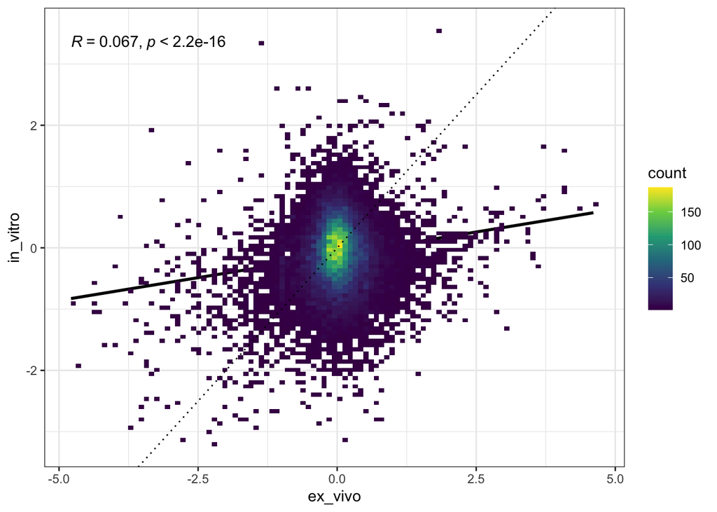

```r
setwd("~/Documents/MiGASti/Databases")
MIGA = "~/Documents/MiGASti/Databases/MIGA_GFM_SVZ.xlsx"
MIGA = read_excel(MIGA, col_names = TRUE)
MIGA = as.data.frame(MIGA)

load("~/Documents/MiGASti/Databases/res_DESEQ_SVZvsGFM.Rdata")
res_D <- as.data.frame(res)
gencode_30 = read.table("~/Documents/MiGASti/Databases/ens.geneid.gencode.v30")
res_2 <- tibble::rownames_to_column(res_D, "ensembl")
colnames(gencode_30) = c("ensembl","symbol")
res3 <- merge(res_2, gencode_30, by = "ensembl")

DEG_MIGA <- MIGA
DEG_MIGASTI <- res3
DEG = merge(DEG_MIGA, DEG_MIGASTI, by ="symbol")

ex_vivo <- DEG[,3]
in_vitro <- DEG[,11]
df = data.frame(ex_vivo, in_vitro)
p1 <- ggplot(df, aes(x=ex_vivo, y=in_vitro) ) +
  geom_smooth(method = "lm", se=FALSE, color="black", formula = y ~ x) +
  geom_bin2d(bins = 100) +
  scale_fill_continuous(type = "viridis") +
  geom_abline(slope = 1, intercept = 0, linetype = 3) +
  theme_bw()
p1 <- p1 + stat_cor(method = "spearman")
p1
```

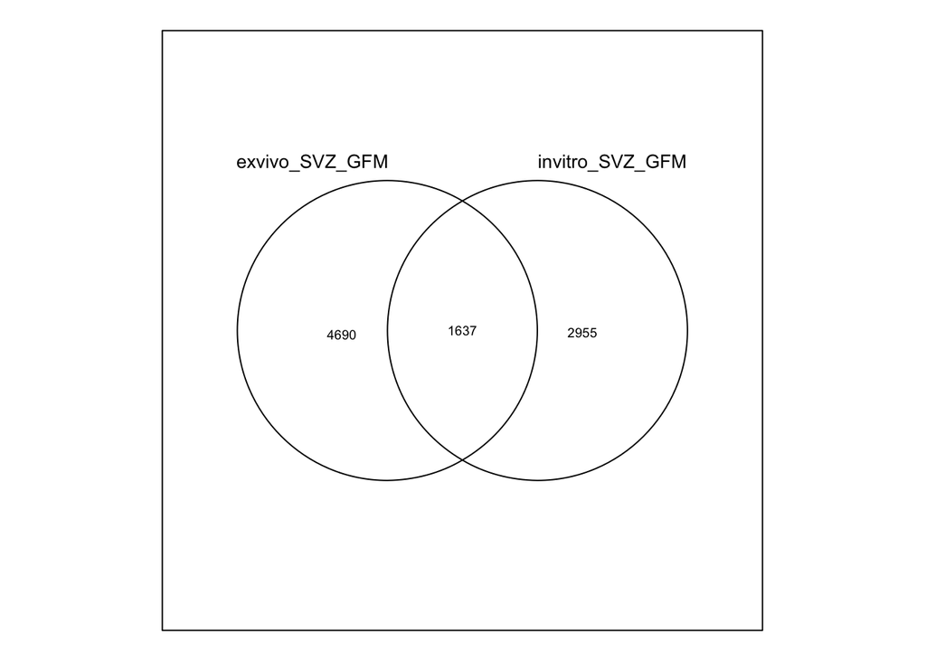

```r
MIGA = "~/Documents/MiGASti/Databases/MIGA_GFM_SVZ.xlsx"
MIGA = read_excel(MIGA, col_names = TRUE)
MIGA = as.data.frame(MIGA)
MIGA$adj.P.Val <- as.numeric(MIGA$adj.P.Val)
MIGA <- MIGA[!duplicated(MIGA$symbol), ]
rownames(MIGA) = MIGA$symbol
load("~/Documents/MiGASti/Databases/res_DESEQ_SVZvsGFM.Rdata")
res_D <- as.data.frame(res)
gencode_30 = read.table("~/Documents/MiGASti/Databases/ens.geneid.gencode.v30")
res_2 <- tibble::rownames_to_column(res_D, "ensembl")
colnames(gencode_30) = c("ensembl","symbol")
res3 <- merge(res_2, gencode_30, by = "ensembl")
res3 <- res3[!duplicated(res3$symbol), ]
rownames(res3) = res3$symbol
df = merge(MIGA, as.data.frame(res3), by=0, all=T)
# ggplot(df, aes(x = -log10(adj.P.Val), y = -log10(padj))) + geom_point(alpha=0.5)
ll = list(exvivo_SVZ_GFM = rownames(MIGA[which(MIGA$adj.P.Val<0.05),]),
     invitro_SVZ_GFM = rownames(res3[which(res3$padj<0.05),]))
venn(ll)
```

### Scatterplot FDR 5% in vitro + ex vivo SVZ x GFM

```r
MIGA = "~/Documents/MiGASti/Databases/MIGA_GFM_SVZ.xlsx"
MIGA = read_excel(MIGA, col_names = TRUE)
MIGA = as.data.frame(MIGA)
MIGA$adj.P.Val <- as.numeric(MIGA$adj.P.Val)
MIGA2 <- subset(MIGA, adj.P.Val < 0.05)
MIGA2 <- MIGA2[!duplicated(MIGA2$symbol), ]
load("~/Documents/MiGASti/Databases/res_DESEQ_SVZvsGFM.Rdata")
res_D <- as.data.frame(res)
gencode_30 = read.table("~/Documents/MiGASti/Databases/ens.geneid.gencode.v30")
res_2 <- tibble::rownames_to_column(res_D, "ensembl")
colnames(gencode_30) = c("ensembl","symbol")
res3 <- merge(res_2, gencode_30, by = "ensembl")
res3 <- res3[!duplicated(res3$symbol), ]
rownames(res3) = res3$symbol
MIGASTI <- subset(res3, padj < 0.05)
ex_in <- merge(MIGA2, MIGASTI, by ="symbol")

list(ex_in$symbol)
```

[[1]] [1] “A2MP1” “AAAS” “ABCB1” “ABCB9” “ABCC10”  
[6] “ABCG2” “ABHD2” “ABHD4” “AC002451.1” “AC004408.2” [11] “AC004865.2” “AC004908.2” “AC005224.4” “AC005280.2” “AC005520.5” [16] “AC005696.1” “AC005899.8” “AC005972.3” “AC006001.3” “AC006033.2” [21] “AC006333.2” “AC007114.2” “AC007608.4” “AC007613.1” “AC008124.1” [26] “AC008691.1” “AC008764.6” “AC008937.1” “AC009119.1” “AC010168.2” [31] “AC010173.1” “AC010491.1” “AC010507.1” “AC011139.1” “AC011472.2” [36] “AC011497.2” “AC011498.1” “AC011511.5” “AC011939.1” “AC012150.2” [41] “AC012368.1” “AC016065.1” “AC016405.3” “AC016582.3” “AC016583.1” [46] “AC016745.2” “AC017083.1” “AC018529.2” “AC018630.2” “AC020909.3” [51] “AC022182.2” “AC022182.3” “AC022336.3” “AC022568.1” “AC023157.3” [56] “AC024257.3” “AC024940.2” “AC025171.1” “AC025580.3” “AC027031.2” [61] “AC027307.3” “AC034236.2” “AC068580.4” “AC068587.4” “AC069185.1” [66] “AC072022.2” “AC073130.3” “AC073140.1” “AC073263.2” “AC073352.2” [71] “AC078845.1” “AC079753.1” “AC080013.5” “AC087164.1” “AC087623.2” [76] “AC092117.2” “AC092447.7” “AC093635.1” “AC098679.1” “AC098818.2” [81] “AC099343.3” “AC104134.1” “AC105020.6” “AC105137.2” “AC107959.4” [86] “AC114977.1” “AC116353.5” “AC116366.1” “AC119428.2” “AC123595.1” [91] “AC124283.1” “AC131206.1” “AC132192.2” “AC135279.3” “AC137767.1” [96] “AC142472.1” “AC144652.1” “AC211476.2” “AC215522.2” “AC226118.1” [101] “AC234775.4” “AC239868.2” “AC242376.2” “AC243772.2” “AC243960.1” [106] “AC243960.3” “AC244453.2” “ACBD3” “ACBD5” “ACER3”  
[111] “ACKR3” “ACLY” “ACO1” “ACO2” “ACOT11”  
[116] “ACOT4” “ACP2” “ACPP” “ACSL1” “ACTA2”  
[121] “ACTN1” “ACVR2A” “AD000864.2” “ADAM9” “ADAMTS1”  
[126] “ADAMTS4” “ADAMTS9” “ADCK5” “ADCY9” “ADD3”  
[131] “ADGRE3” “ADGRL4” “ADIRF” “ADNP2” “ADRB1”  
[136] “ADSSL1” “AF117829.1” “AF127936.1” “AF213884.3” “AGGF1”  
[141] “AGL” “AGMAT” “AHCY” “AIFM2” “AIFM3”  
[146] “AK1” “AKAP12” “AKAP2” “AKR1B1” “AKR1C2”  
[151] “AKTIP” “AL008729.1” “AL008729.2” “AL021155.2” “AL024507.2” [156] “AL031056.2” “AL031733.2” “AL031777.1” “AL031777.3” “AL034428.1” [161] “AL096870.2” “AL109840.2” “AL121987.2” “AL135925.1” “AL135960.1” [166] “AL136531.3” “AL137060.1” “AL137186.2” “AL139385.1” “AL158071.3” [171] “AL158071.4” “AL160408.2” “AL162458.1” “AL353708.3” “AL354707.1” [176] “AL355075.4” “AL356273.3” “AL357054.4” “AL357078.3” “AL358933.1” [181] “AL359644.1” “AL359711.2” “AL359844.1” “AL365209.1” “AL391684.1” [186] “AL589743.1” “AL603756.1” “AL606834.1” “AL645728.1” “AL662844.4” [191] “AL845472.2” “ALAS2” “ALCAM” “ALDH18A1” “ALDH1A2”  
[196] “ALDH1A3” “ALDH1L1” “ALDH2” “ALDH3B1” “ALDH9A1”  
[201] “ALG12” “ALKAL2” “ALKBH7” “ALOX5AP” “ALPL”  
[206] “AMT” “ANAPC5” “ANG” “ANGPT2” “ANK1”  
[211] “ANKRD16” “ANKRD22” “ANKRD37” “ANKRD39” “ANKRD6”  
[216] “ANKRD9” “ANPEP” “ANXA2R” “ANXA3” “ANXA6”  
[221] “AOAH” “AP000331.1” “AP000879.1” “AP000911.1” “AP001437.1” [226] “AP002807.1” “AP002884.1” “AP002956.1” “AP003392.3” “AP003774.1” [231] “AP005530.1” “AP005717.1” “AP1S3” “APBA2” “APCDD1”  
[236] “APH1A” “APOBEC3A” “APOBEC3D” “APOC1” “APOL4”  
[241] “APOLD1” “APPL2” “ARAP1” “ARC” “AREG”  
[246] “ARF3” “ARG1” “ARG2” “ARHGAP10” “ARHGAP18”  
[251] “ARHGAP9” “ARHGDIA” “ARHGEF37” “ARIH1” “ARL4C”  
[256] “ARMC6” “ARMCX4” “ARRDC3” “ARSA” “ASAH1”  
[261] “ASCL4” “ATF3” “ATG7” “ATP6V1C1” “ATP6V1G2”  
[266] “ATP8A1” “AZIN1” “B3GALNT1” “B3GNTL1” “B4GALNT1”  
[271] “BACH2” “BAG1” “BAG3” “BAMBI” “BAZ1A”  
[276] “BBS9” “BCAP31” “BCKDHA” “BCL2” “BCO2”  
[281] “BCYRN1” “BEND3” “BICDL2” “BIN2” “BLNK”  
[286] “BMI1” “BMX” “BNC2” “BNIPL” “BPI”  
[291] “BRINP2” “BRK1” “BSCL2” “BSG” “BTBD11”  
[296] “BX255925.3” “C10orf55” “C11orf1” “C11orf24” “C16orf58”  
[301] “C16orf87” “C17orf49” “C17orf67” “C17orf80” “C19orf38”  
[306] “C19orf66” “C1orf162” “C1orf216” “C1orf56” “C1orf61”  
[311] “C1QA” “C1QTNF1” “C1S” “C2CD2” “C4orf19”  
[316] “C4orf3” “C5AR1” “C6orf47” “C6orf48” “C8orf88”  
[321] “C9orf24” “CA5BP1” “CA8” “CACNA2D3” “CAHM”  
[326] “CALCR” “CALD1” “CALR” “CAMK2A” “CAMK2B”  
[331] “CAMSAP2” “CAPG” “CAPN12” “CARS-AS1” “CASC4”  
[336] “CASP10” “CASP4” “CASP8” “CASS4” “CAST”  
[341] “CAV2” “CBX3P4” “CCDC121” “CCDC50” “CCDC69”  
[346] “CCDC81” “CCDC96” “CCK” “CCL20” “CCNB2”  
[351] “CCNG2” “CCNI” “CCNT1” “CCR2” “CCS”  
[356] “CCSAP” “CD101” “CD14” “CD163L1” “CD177”  
[361] “CD2” “CD200R1” “CD22” “CD24” “CD247”  
[366] “CD320” “CD37” “CD44” “CD46” “CD48”  
[371] “CD52” “CD68” “CD69” “CD8A” “CD9”  
[376] “CD93” “CDA” “CDCP1” “CDH5” “CDK5RAP3”  
[381] “CDKN2AIP” “CDKN2B” “CDKN2C” “CDPF1” “CDS1”  
[386] “CEACAM3” “CEACAM8” “CECR7” “CENPT” “CENPV”  
[391] “CEP120” “CEP128” “CFAP74” “CHAC1” “CHD6”  
[396] “CHML” “CHMP6” “CHN1” “CHPF2” “CIART”  
[401] “CIZ1” “CKAP5” “CKS2” “CLDN5” “CLEC12A”  
[406] “CLEC17A” “CLIC5” “CLK1” “CLUL1” “CMPK1”  
[411] “CNBD2” “CNDP2” “CNEP1R1” “CNN1” “CNOT6”  
[416] “CNTNAP2” “COA6-AS1” “COASY” “COL15A1” “COL17A1”  
[421] “COMMD3” “COPS7A” “COQ7” “CORO1C” “COX7A1”  
[426] “CPEB3” “CPLX2” “CPM” “CPPED1” “CRELD1”  
[431] “CRIP2” “CRISP3” “CRISPLD2” “CRNDE” “CS”  
[436] “CSE1L” “CSF1” “CSKMT” “CSNK2A1” “CSPG4”  
[441] “CST7” “CSTB” “CSTF2” “CTNNA1” “CTNNB1”  
[446] “CTNNBL1” “CTNND2” “CTSA” “CTSD” “CTSL”  
[451] “CTSV” “CTTNBP2” “CXADR” “CXCL10” “CXCL9”  
[456] “CXCR2” “CXXC1” “CYB561D2” “CYBC1” “CYFIP2”  
[461] “CYTH1” “CYTH4” “DAAM1” “DACH2” “DBF4”  
[466] “DBP” “DCBLD1” “DCTN1” “DDA1” “DDOST”  
[471] “DDX11” “DELE1” “DENND1B” “DENND2D” “DENND5A”  
[476] “DEPDC7” “DEPTOR” “DHCR24” “DHCR7” “DHPS”  
[481] “DHRS4” “DHX33” “DIAPH1” “DIRC3” “DISP1”  
[486] “DKK1” “DLC1” “DLEU2” “DLG2” “DMRTA1”  
[491] “DNAJA4” “DNAJB4” “DNAJC27” “DNAJC27-AS1” “DNAJC3-DT”  
[496] “DNER” “DNTTIP2” “DOCK1” “DOCK2” “DOK3”  
[501] “DOLK” “DPAGT1” “DPH7” “DPM2” “DPP4”  
[506] “DPP7” “DPP9” “DPYD” “DPYSL3” “DRAM2”  
[511] “DSEL” “DST” “DUSP1” “DUSP10” “DUSP2”  
[516] “DUSP28” “DUSP4” “DUSP5” “DUXAP8” “DUXAP9”  
[521] “DYSF” “E2F6” “EBLN3P” “ECM1” “EDN1”  
[526] “EDNRA” “EDNRB” “EEF1D” “EFCAB2” “EFNA1”  
[531] “EGLN3” “EGR1” “EGR2” “EGR3” “EHD1”  
[536] “EHD2” “EIF2AK3” “EIF2AK3-DT” “EIF2B1” “EIF2S3”  
[541] “EIF3C” “EIF4E” “ELF1” “ELOVL1” “EMB”  
[546] “ENHO” “ENO1-AS1” “ENO2” “ENO3” “ENOSF1”  
[551] “ENTPD4” “EPB41L3” “EPM2A” “ERCC3” “EREG”  
[556] “ERG” “ERGIC3” “ERP44” “ERRFI1” “ESAM”  
[561] “ESYT1” “ETV7” “EVL” “EXOC2” “EXOC3”  
[566] “EXOC6” “EYA4” “F11R” “F2R” “F2RL1”  
[571] “FADD” “FAF2” “FAM107A” “FAM110B” “FAM114A1”  
[576] “FAM157C” “FAM184A” “FAM210A” “FAM234A” “FAM43A”  
[581] “FAM72A” “FAM72B” “FAM72C” “FAM72D” “FAM84B”  
[586] “FAM87B” “FAM98A” “FASTK” “FBF1” “FBXL14”  
[591] “FBXO31” “FBXO9” “FCER1A” “FCGR3B” “FCGRT”  
[596] “FCN1” “FES” “FFAR4” “FGD2” “FGD3”  
[601] “FGD6” “FGF13” “FGFBP3” “FGFR1” “FHL2”  
[606] “FLNA” “FLVCR1-DT” “FNDC3A” “FNTB” “FOLR2”  
[611] “FOLR3” “FOS” “FOSB” “FOSL1” “FOXP2”  
[616] “FP565260.3” “FPR2” “FRZB” “FXN” “FXYD2”  
[621] “FXYD5” “GABPB1-AS1” “GADD45B” “GALC” “GALK1”  
[626] “GANAB” “GAP43” “GAPDH” “GARNL3” “GAS1”  
[631] “GAS2” “GAS5” “GAS7” “GASK1A” “GATA2”  
[636] “GBP1” “GBP2” “GBP4” “GCC2-AS1” “GCLC”  
[641] “GCNA” “GDF15” “GEM” “GFI1” “GFOD1”  
[646] “GGTA1P” “GHET1” “GIMAP1” “GIMAP7” “GJA4”  
[651] “GJB6” “GJC1” “GLB1” “GLIPR1” “GLIPR2”  
[656] “GLO1” “GLT1D1” “GLUD1” “GMPPA” “GMPR”  
[661] “GMPS” “GNA12” “GNAL” “GNB4” “GNE”  
[666] “GNG3” “GNS” “GOLIM4” “GOT2” “GPAT4”  
[671] “GPC4” “GPD2” “GPER1” “GPI” “GPNMB”  
[676] “GPR108” “GPR146” “GPR151” “GPR4” “GPRC5D-AS1” [681] “GPX1” “GRIK4” “GSDME” “GSPT1” “GSTM2”  
[686] “GSTM3” “GSTO2” “GTF2F2” “GTF2IRD2B” “GTPBP4”  
[691] “GYPC” “GZMH” “H1F0” “H2AFX” “H3F3B”  
[696] “HACD1” “HACD2” “HADHA” “HADHB” “HARBI1”  
[701] “HAVCR1” “HBA2” “HBB” “HBEGF” “HBP1”  
[706] “HCAR2” “HCAR3” “HCG27” “HCK” “HDGF”  
[711] “HECA” “HECTD2” “HERC2P2” “HES1” “HEY2”  
[716] “HIF1A” “HIGD1B” “HIST1H2BB” “HIST1H2BE” “HIST1H2BF”  
[721] “HIST1H2BH” “HIST1H3C” “HIST1H3H” “HIST2H2BB” “HIST2H2BF”  
[726] “HIST2H4B” “HIVEP3” “HK1” “HKR1” “HLA-J”  
[731] “HLA-V” “HMGB2” “HMGN4” “HMOX1” “HNRNPU”  
[736] “HOPX” “HP” “HPSE” “HS2ST1” “HS3ST3B1”  
[741] “HSD17B4” “HSH2D” “HSP90AA1” “HSP90AA2P” “HSP90AB3P”  
[746] “HSPA1A” “HSPA1B” “HSPA1L” “HSPA2” “HSPA6”  
[751] “HSPB1” “HSPB9” “HSPE1” “HSPH1” “HTATIP2”  
[756] “HTR2B” “HYDIN” “HYMAI” “HYOU1” “HYPK”  
[761] “IARS2” “ICAM5” “IDS” “IER5” “IFI27”  
[766] “IFITM1” “IFNB1” “IFNLR1” “IFT57” “IGF1”  
[771] “IGFBP4” “IGFBP6” “IGFBP7” “IGKC” “IGSF21”  
[776] “IL15RA” “IL1B” “IL1R2” “IL1RL1” “IL23A”  
[781] “IL32” “IL3RA” “IL6R-AS1” “IMMT” “IMPA2”  
[786] “IMPACT” “INA” “ING1” “INPP5F” “INTS10”  
[791] “IRAK4” “IRF2BP2” “IRF3” “IRS3P” “ITGA2”  
[796] “ITGA4” “ITGA9” “ITGAL” “ITGAM” “ITGB8”  
[801] “ITM2A” “ITM2C” “ITPKB” “ITPR1” “JAG1”  
[806] “JAML” “JMJD7” “JOSD2” “JTB” “JUN”  
[811] “KANK2” “KBTBD12” “KCNA5” “KCNE4” “KCNG3”  
[816] “KCNJ15” “KCNJ5” “KCNMA1” “KCTD12” “KDM5B”  
[821] “KDSR” “KIAA0930” “KIAA1586” “KIF19” “KIF20B”  
[826] “KIN” “KL” “KLF10” “KLF11” “KLF2”  
[831] “KLF4” “KLF6” “KLHL12” “KLHL20” “KLHL24”  
[836] “KLHL31” “KLHL9” “KLRK1” “KRI1” “KRT17P1”  
[841] “KRT17P6” “L3MBTL4-AS1” “LAMA5” “LAMP3” “LAT”  
[846] “LCK” “LCN2” “LDHA” “LDHD” “LENG8-AS1”  
[851] “LEPROTL1” “LGALS1” “LGALS3BP” “LIF” “LIMS2”  
[856] “LIN7A” “LINC00294” “LINC00346” “LINC00578” “LINC00612”  
[861] “LINC00653” “LINC00702” “LINC00892” “LINC00920” “LINC00958”  
[866] “LINC00987” “LINC00996” “LINC01003” “LINC01128” “LINC01354”  
[871] “LINC01465” “LINC01554” “LINC01578” “LINC01679” “LINC02068”  
[876] “LINC02158” “LINC02232” “LINC02432” “LINC02642” “LIPG”  
[881] “LIX1L” “LMAN2” “LMF1” “LMF1-AS1” “LNPK”  
[886] “LOH12CR2” “LONRF1” “LONRF3” “LPAR5” “LPCAT2”  
[891] “LPCAT3” “LRCH3” “LRIG1” “LRIG3” “LRMP”  
[896] “LRP5L” “LRRC2” “LRRC23” “LRRC25” “LRRC59”  
[901] “LRRC8A” “LRRC8C” “LTA4H” “LTB” “LTB4R”  
[906] “LTF” “LYSMD1” “LYST” “LYVE1” “MAD1L1”  
[911] “MAF” “MAFF” “MAG” “MAGED2” “MAGI1”  
[916] “MAP1LC3B” “MAP2” “MAP3K2” “MAP3K2-DT” “MAP3K21”  
[921] “MAP3K4” “MAP3K7CL” “MAP4K3” “MAP6” “MAP7D2”  
[926] “MARCO” “MATN1-AS1” “MAVS” “MBD4” “MBOAT2”  
[931] “MCEE” “MCF2L2” “MCMBP” “MCOLN2” “MCRS1”  
[936] “ME1” “MED12L” “MED17” “MED22” “MEGF6”  
[941] “MEIS2” “MELTF” “MESD” “MESTIT1” “METRNL”  
[946] “METTL17” “MEX3B” “MFSD1” “MFSD9” “MGP”  
[951] “MGST2” “MIB1” “MIGA2” “MIIP” “MINK1”  
[956] “MIR100HG” “MIR17HG” “MIR31HG” “MIR4435-2HG” “MIS18BP1”  
[961] “MITF” “MKNK1” “MLST8” “MMGT1” “MMP14”  
[966] “MMP8” “MMP9” “MNDA” “MORC2-AS1” “MOV10L1”  
[971] “MPP7” “MPZL3” “MRC1” “MRO” “MRPL20-AS1” [976] “MRVI1” “MS4A7” “MSANTD2” “MSI2” “MSL3”  
[981] “MSN” “MSTO1” “MSX1” “MT-ND3” “MTG1”  
[986] “MTM1” “MTUS1” “MUS81” “MUSTN1” “MVD”  
[991] “MXI1” “MYD88” “MYH15” “MYO1B” “MYO1F”  
[996] “MYO5B” “MYO7A” “MYOZ2” “NADSYN1” “NAF1”  
[1001] “NARS” “NAT10” “NAV3” “NBDY” “NBEAL2”  
[1006] “NCDN” “NCF4” “NDRG2” “NDUFA4L2” “NDUFAF5”  
[1011] “NDUFV2-AS1” “NEDD4L” “NEDD9” “NEFL” “NEFM”  
[1016] “NEK7” “NETO2” “NFE2” “NFE2L3” “NFE4”  
[1021] “NFKB1” “NHS” “NIPAL4” “NISCH” “NIT1”  
[1026] “NKG7” “NKILA” “NKRF” “NLRP12” “NLRP6”  
[1031] “NMB” “NME3” “NMRK1” “NOMO2” “NPC2”  
[1036] “NPL” “NPM3” “NPTN” “NR1D2” “NR4A1”  
[1041] “NR4A3” “NRARP” “NRN1” “NSF” “NSMAF”  
[1046] “NSMCE1-DT” “NSUN7” “NTN4” “NUB1” “NUCB2”  
[1051] “NUDT22” “NUDT4” “NUDT5” “NUP85” “OAZ2”  
[1056] “ODC1” “OGDH” “OGFRL1” “OLFM1” “OLFM4”  
[1061] “ORAI3” “ORM1” “OSBPL8” “OSTF1” “OTUD4”  
[1066] “OTULIN” “OVOL1” “OXR1” “P2RY12” “P2RY13”  
[1071] “P2RY6” “P3H4” “P4HA1” “PADI1” “PADI4”  
[1076] “PAK2” “PAK6” “PAPSS1” “PAPSS2” “PAQR8”  
[1081] “PARD6G-AS1” “PARP16” “PARP4” “PAXIP1-AS1” “PBX3”  
[1086] “PCBD1” “PCBP3” “PCDHGB5” “PCGF3” “PCGF5”  
[1091] “PCSK5” “PCYOX1L” “PDCD6IPP2” “PDE3A” “PDE4C”  
[1096] “PDE7B” “PDGFA” “PDGFC” “PDK4” “PDP1”  
[1101] “PDPN” “PELI2” “PEPD” “PEX19” “PFKFB3”  
[1106] “PFKL” “PGAP3” “PGBD2” “PGK1” “PGLYRP1”  
[1111] “PGM2” “PHACTR1” “PHACTR3” “PHETA2” “PHKB”  
[1116] “PHYH” “PI3” “PI4K2A” “PIK3R1” “PIK3R3”  
[1121] “PIK3R6” “PILRA” “PIP4P2” “PIP5K1B” “PIPOX”  
[1126] “PJA1” “PKIB” “PKM” “PLA1A” “PLA2G7”  
[1131] “PLAT” “PLAUR” “PLEKHA5” “PLEKHG3” “PLEKHG5”  
[1136] “PLEKHH2” “PLK2” “PLPP1” “PLPPR2” “PLXDC1”  
[1141] “PLXDC2” “PMAIP1” “PNMA8A” “PNRC1” “POC1B-AS1”  
[1146] “PODXL” “PODXL2” “POLR1C” “POLR2J3” “POMGNT1”  
[1151] “POMT1” “POU3F1” “PPARD” “PPARG” “PPDPF”  
[1156] “PPIB” “PPIL2” “PPM1E” “PPM1F” “PPP1R15A”  
[1161] “PPP1R3B” “PPP1R3C” “PPP2R5B” “PPP4R3A” “PRDX5”  
[1166] “PRDX6” “PREP” “PRKCA” “PRMT2” “PROK2”  
[1171] “PROX1” “PRPF38B” “PRPF6” “PRPSAP2” “PRRG4”  
[1176] “PRRT1” “PRRT2” “PRRT3” “PRSS12” “PRSS23”  
[1181] “PRSS8” “PSD3” “PTCD1” “PTDSS1” “PTGER4”  
[1186] “PTGFRN” “PTGS1” “PTP4A1” “PTP4A3” “PTPN7”  
[1191] “PTTG1” “PUS10” “PVT1” “PWWP2B” “PXN”  
[1196] “PYGB” “PYGO2” “QTRT2” “RAB13” “RAB1B”  
[1201] “RAB21” “RAB24” “RAB26” “RAB37” “RAB40B”  
[1206] “RAB5B” “RAB6B” “RAC2” “RALGPS1” “RAP1GDS1”  
[1211] “RAP2B” “RAPGEF1” “RAPGEF4” “RAPH1” “RASA1”  
[1216] “RASAL2” “RASAL2-AS1” “RASGEF1B” “RASGRP2” “RASL10A”  
[1221] “RASL11B” “RASSF10” “RCAN2” “RCCD1” “RCOR1”  
[1226] “REEP4” “RETN” “REX1BD” “RGL2” “RGL4”  
[1231] “RGMB-AS1” “RGS1” “RGS13” “RGS14” “RGS16”  
[1236] “RGS18” “RGS2” “RGS20” “RGS4” “RGS5”  
[1241] “RHOA” “RHOBTB3” “RHOT2” “RIPK3” “RMND5A”  
[1246] “RN7SL187P” “RNASE1” “RNF103” “RNF139-AS1” “RNF20”  
[1251] “RNF216” “RNH1” “RNMT” “RPARP-AS1” “RPL10P7”  
[1256] “RPL28” “RPS20P22” “RRAD” “RRM1” “RRN3P1”  
[1261] “RTL8A” “RUBCNL” “RUNDC3A” “RUNDC3B” “RUNX3”  
[1266] “RYBP” “RYR1” “S100A10” “S100A12” “S100A6”  
[1271] “S100A9” “S100P” “S100Z” “S1PR1” “S1PR3”  
[1276] “S1PR4” “SARAF” “SARS2” “SCCPDH” “SCD”  
[1281] “SCPEP1” “SCRN2” “SCUBE2” “SDAD1P1” “SDC4”  
[1286] “SDSL” “SEC23B” “SEC61A2” “SECISBP2” “SELENBP1”  
[1291] “SELENOM” “SELENOP” “SELL” “SEMA4B” “SEPT10”  
[1296] “SEPT2” “SEPT5” “SERINC2” “SERINC5” “SERPINE1”  
[1301] “SERPING1” “SETD3” “SFXN2” “SFXN3” “SGK1”  
[1306] “SGSM3” “SH2D1B” “SH3BGRL” “SH3GL2” “SH3PXD2A”  
[1311] “SHC3” “SHE” “SIDT1” “SIGLEC12” “SIGLEC5”  
[1316] “SIPA1L1” “SIRT1” “SLAMF8” “SLC11A1” “SLC15A2”  
[1321] “SLC16A10” “SLC17A7” “SLC19A2” “SLC1A1” “SLC22A18”  
[1326] “SLC25A23” “SLC25A24” “SLC25A33” “SLC30A10” “SLC33A1”  
[1331] “SLC35A2” “SLC35G1” “SLC37A3” “SLC37A4” “SLC39A1”  
[1336] “SLC39A13” “SLC39A8” “SLC39A9” “SLC40A1” “SLC43A3”  
[1341] “SLC52A2” “SLC5A3” “SLC7A7” “SLC9A3R1” “SLC9A6”  
[1346] “SLC9A7” “SLCO2B1” “SLCO4C1” “SLFN11” “SLIT3”  
[1351] “SMAD7” “SMG7-AS1” “SMIM10L1” “SMIM13” “SMIM25”  
[1356] “SMPD3” “SMTN” “SMURF2” “SMYD2” “SNAI1”  
[1361] “SNAP25” “SNAPC2” “SNCA” “SNCG” “SND1”  
[1366] “SNHG10” “SNHG15” “SNIP1” “SNRPA” “SNX30”  
[1371] “SOCS1” “SOCS2” “SORBS2” “SOX9” “SP110”  
[1376] “SPAG5-AS1” “SPARCL1” “SPATA18” “SPECC1” “SPINT2”  
[1381] “SPIRE1” “SPIRE2” “SPOUT1” “SPP1” “SPRY1”  
[1386] “SPSB1” “SPTY2D1OS” “SQSTM1” “SRGAP2-AS1” “SRI”  
[1391] “SRL” “SRSF1” “SRXN1” “SSBP2” “SSC5D”  
[1396] “ST20-AS1” “ST6GALNAC2” “ST8SIA4” “STAB1” “STAM-AS1”  
[1401] “STBD1” “STMN2” “STON2” “STRADA” “STRBP”  
[1406] “STX10” “STX16” “STX6” “SUCNR1” “SUGP2”  
[1411] “SULT1A1” “SULT4A1” “SUMO3” “SVIL” “SYCP2”  
[1416] “SYCP2L” “SYNE2” “SYP” “SYT4” “SYTL3”  
[1421] “TAGLN” “TANC2” “TAX1BP3” “TBC1D14” “TBC1D15”  
[1426] “TBC1D16” “TBC1D22A” “TBC1D9B” “TCN2” “TCTA”  
[1431] “TDRD10” “TDRD6” “TEK” “TEKT1” “TELO2”  
[1436] “TENT5A” “TENT5C” “TERF2” “TFCP2” “TGFB2”  
[1441] “TGFBI” “TGM2” “THUMPD2” “TIAF1” “TIGD3”  
[1446] “TIMD4” “TIMP3” “TIRAP” “TLE1” “TLE4”  
[1451] “TLK1” “TLK2” “TLN1” “TLN2” “TLR10”  
[1456] “TLR5” “TM4SF18” “TM9SF2” “TMBIM1” “TMBIM4”  
[1461] “TMCO6” “TMED5” “TMEM104” “TMEM115” “TMEM120A”  
[1466] “TMEM144” “TMEM150A” “TMEM161A” “TMEM163” “TMEM168”  
[1471] “TMEM191A” “TMEM202-AS1” “TMEM204” “TMEM205” “TMEM209”  
[1476] “TMEM255B” “TMEM268” “TMEM273” “TMEM50B” “TMEM69”  
[1481] “TMIGD2” “TMOD1” “TMSB15B” “TMUB2” “TNFAIP1”  
[1486] “TNFAIP8L2” “TNFRSF12A” “TNFRSF13C” “TNFSF10” “TNFSF4”  
[1491] “TNFSF9” “TNIK” “TNIP1” “TNS1” “TNS3”  
[1496] “TOB1-AS1” “TOM1” “TOMM40L” “TP53BP2” “TPD52L1”  
[1501] “TPGS2” “TPM2” “TPRG1” “TPRG1-AS1” “TRA2B”  
[1506] “TRAF3IP3” “TRAF4” “TRAF6” “TRAPPC11” “TRBC1”  
[1511] “TRGC2” “TRIB1” “TRIM27” “TRIM45” “TRMT2A”  
[1516] “TRMU” “TRPM2” “TRPS1” “TRPV4” “TSC22D1”  
[1521] “TSPAN2” “TSPAN7” “TSPO” “TSTD1” “TTC25”  
[1526] “TTC31” “TTC39A” “TTF2” “TUBA1B” “TUBB2B”  
[1531] “TUBG1” “TUBGCP6” “TXLNA” “TYW5” “U2AF1L4”  
[1536] “U47924.2” “UBA1” “UBC” “UBXN2B” “UGGT1”  
[1541] “UHMK1” “UHRF2” “UNC5C” “USP12” “USP51”  
[1546] “USP53” “USP6” “VAMP1” “VAMP3” “VAMP8”  
[1551] “VASP” “VCPKMT” “VEGFB” “VMO1” “VPS16”  
[1556] “VPS35” “VPS41” “VSIG4” “VSNL1” “VSTM4”  
[1561] “WAC” “WBP1L” “WDFY2” “WDR11” “WDR24”  
[1566] “WDR48” “WDR77” “WEE1” “WFS1” “WHRN”  
[1571] “WIPF3” “WIPI2” “WNT5B” “WTAP” “XPO7”  
[1576] “XRCC1” “YBX3” “YPEL4” “YTHDC2” “YWHAQ”  
[1581] “YY1” “Z93241.1” “ZBTB10” “ZBTB18” “ZBTB2”  
[1586] “ZDHHC12” “ZFAND2A” “ZFAND5” “ZFPM2-AS1” “ZFYVE9”  
[1591] “ZMYM5” “ZNF101” “ZNF14” “ZNF154” “ZNF230”  
[1596] “ZNF350” “ZNF354B” “ZNF395” “ZNF415” “ZNF417”  
[1601] “ZNF420” “ZNF43” “ZNF430” “ZNF431” “ZNF433”  
[1606] “ZNF506” “ZNF507” “ZNF512” “ZNF528” “ZNF540”  
[1611] “ZNF542P” “ZNF554” “ZNF556” “ZNF583” “ZNF585A”  
[1616] “ZNF586” “ZNF587” “ZNF595” “ZNF626” “ZNF639”  
[1621] “ZNF674-AS1” “ZNF675” “ZNF682” “ZNF701” “ZNF711”  
[1626] “ZNF724” “ZNF738” “ZNF766” “ZNF790” “ZNF808”  
[1631] “ZNF814” “ZNF83” “ZNF844” “ZNF90” “ZRANB1”  
[1636] “ZSCAN18” “ZSCAN31”

```r
genelist <- merge(Patir, ex_in, by = "symbol")
list(genelist$symbol)
```

[[1]] [1] “ALOX5AP” “AOAH” “BIN2” “BLNK” “C1QA” “CAPG”  
[7] “CD14” “CD37” “CD68” “CD69” “CLEC17A” “CYTH4”  
[13] “DOCK2” “FCGR3B” “FGD2” “HCK” “ITGAL” “ITGAM”  
[19] “LPAR5” “MNDA” “MS4A7” “MYO1F” “NCF4” “P2RY12”  
[25] “P2RY13” “PLXDC2” “RAC2” “REEP4” “RGS1” “RGS18”  
[31] “SLC11A1” “SLC7A7” “SPP1” “STAB1” “SUCNR1” “SYTL3”  
[37] “TLR10” “TLR5” “TNFAIP8L2” “TNFRSF13C” “TRAF3IP3” “VAMP8”  
[43] “VSIG4”

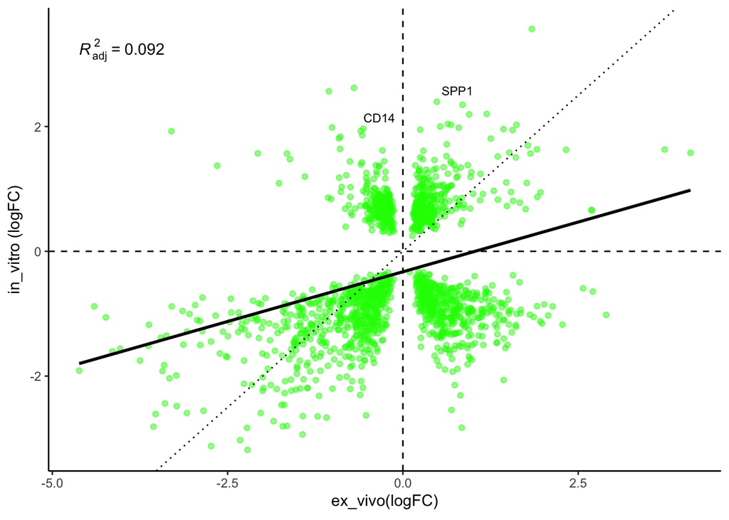

```r
ex_vivo <- ex_in[,3]
in_vitro <- ex_in[,11]
df = data.frame(ex_vivo, in_vitro)

rownames(df) = ex_in$symbol

symbol4label = c("TLR6", "TYROBP", "TBXAS1", "TLR1", "TREM2", "ITGAM", "IRF5", "CD14", "CD33", "MS4A4A", "SPP1", "CSF1R", "C3")
genes_m_filt4lab = df
genes_m_filt4lab$overlap = rownames(genes_m_filt4lab)
genes_m_filt4lab$overlap[(!genes_m_filt4lab$overlap %in% symbol4label)] = ""


p3 <-  ggplot(genes_m_filt4lab, aes(x = ex_vivo, y = in_vitro)) +
  geom_point(alpha=.5, color="green")+
  geom_hline(yintercept = 0, linetype = "dashed", colour = "black") +
  geom_vline(xintercept = 0, linetype = "dashed", colour = "black") +
  stat_smooth(method = "lm", se=F, color="black") + # Add Regression Line
  stat_regline_equation(aes(label = ..adj.rr.label..), show.legend = F)  +
  geom_abline(slope = 1, intercept = 0, linetype = 3)
p3 + geom_text_repel(aes(label = overlap),
                    size = 3) + easy_labs(x = expression(paste("ex_vivo(", logFC,")")), y = expression(paste("in_vitro (", logFC, ")"))) +
  theme_classic()
```

### Overlap up SVZ ex vivo + in vitro up SVZ (logFC >1)

```r
set3 <- subset(MIGA, adj.P.Val < 0.05)
set3 <- subset(set3, logFC > 1)
set4 <- subset(res3, padj < 0.05)
set4 <- subset(res3, log2FoldChange > 1)

overlap <- merge(set3, set4, by = "symbol")
list(overlap$symbol)
```

[[1]] [1] “AC063949.2” “ACKR3” “AREG” “ARL4C” “C9orf24”  
[6] “CCL20” “CD9” “CENPVL3” “DPYD” “EREG”  
[11] “ITGA4” “ITGB8” “KRT17P1” “KRT17P2” “KRT17P6”  
[16] “MAG” “MCOLN2” “METRNL” “SERINC2” “TEKT1”  
[21] “TPRG1-AS1”

```r
set1 <- set3
set2 <- set4

set1_v <- set1$symbol
set2_v <- set2$symbol

setEnrichment( set1 = set1_v, set2 = set2_v)
```

| set1_length | set2_length | overlap | ratio | p.value |
| --- | --- | --- | --- | --- |
| 549 | 607 | 21 | 1.280377 | 0.1654529 |

### Overlap soqn SVZ ex vivo + in vitro down SVZ (logFC < -1)

```r
set3 <- subset(MIGA, adj.P.Val < 0.05)
set3 <- subset(set3, logFC < -1)
set4 <- subset(res3, padj < 0.05)
set4 <- subset(set4, log2FoldChange < - 1)

overlap <- merge(set3, set4, by = "symbol")
list(overlap$symbol)
```

[[1]] [1] “A2MP1” “ABCG2” “AC004408.2” “AC011139.1” “AC011472.2” [6] “AC016582.3” “AC016583.1” “AC022568.1” “AC092447.7” “AC131206.1” [11] “ACTA2” “ADAMTS1” “ADAMTS4” “ADGRL4” “ADIRF”  
[16] “AL359844.1” “ALAS2” “ALPL” “AP005717.1” “APOBEC3A”  
[21] “ARG1” “ASCL4” “BCYRN1” “BMX” “BPI”  
[26] “BRINP2” “CA8” “CALCR” “CAMK2B” “CD163L1”  
[31] “CD177” “CD2” “CD200R1” “CD52” “CD8A”  
[36] “CDA” “CDH5” “CEACAM3” “CEACAM8” “CFAP74”  
[41] “CLDN5” “CNN1” “COL17A1” “COX7A1” “CPLX2”  
[46] “CRIP2” “CRISP3” “CSPG4” “CXCR2” “EDNRA”  
[51] “EHD2” “ENHO” “ESAM” “ETV7” “FAM107A”  
[56] “FAM72C” “FCGR3B” “FCN1” “FOLR2” “FOLR3”  
[61] “FRZB” “GAP43” “GATA2” “GIMAP7” “GJA4”  
[66] “GJB6” “GJC1” “GLT1D1” “GNG3” “GPER1”  
[71] “GPR4” “GZMH” “HACD1” “HBA2” “HBB”  
[76] “HIGD1B” “HSH2D” “IFI27” “IFITM1” “IGFBP4”  
[81] “IGFBP6” “IGFBP7” “IL1R2” “IL1RL1” “IL32”  
[86] “INA” “ITM2A” “JAML” “KCNJ15” “LCK”  
[91] “LCN2” “LIMS2” “LINC00578” “LINC00892” “LINC00958” [96] “LINC00996” “LINC02642” “LTF” “LYVE1” “MAP7D2”  
[101] “MPZL3” “MRC1” “MUSTN1” “MYOZ2” “NDUFA4L2”  
[106] “NEFL” “NEFM” “NFE2” “NFE4” “NRN1”  
[111] “NTN4” “OLFM1” “OLFM4” “ORM1” “PADI4”  
[116] “PDE4C” “PGLYRP1” “PI3” “PLA1A” “PLEKHG5”  
[121] “PODXL” “PROK2” “PRRT1” “PTP4A3” “RAPGEF4”  
[126] “RASL10A” “RASSF10” “RCAN2” “RETN” “RGL4”  
[131] “RNASE1” “RUNDC3B” “S100A12” “S100P” “S1PR4”  
[136] “SELENBP1” “SEPT5” “SH2D1B” “SH3GL2” “SHE”  
[141] “SIGLEC12” “SNAP25” “SNCG” “SOCS2” “SPARCL1”  
[146] “SRL” “STMN2” “SUCNR1” “SULT4A1” “TAGLN”  
[151] “TDRD10” “TEK” “TIMP3” “TM4SF18” “TMEM163”  
[156] “TPM2” “TRBC1” “TRGC2” “TSPAN2” “TSPAN7”  
[161] “UNC5C” “VSNL1” “ZFPM2-AS1” “ZNF556”

```r
set1 <- set3
set2 <- set4

set1_v <- set1$symbol
set2_v <- set2$symbol

setEnrichment( set1 = set1_v, set2 = set2_v)
```

| set1_length | set2_length | overlap | ratio | p.value |
| --- | --- | --- | --- | --- |
| 607 | 1293 | 164 | 5.987762 | 3.728843e-59 |

## ex vivo SVZ vs GFM up (logFC > 1)

```r
setwd("~/Documents/MiGASti/Databases")
MIGA = "~/Documents/MiGASti/Databases/MIGA_GFM_SVZ.xlsx"
MIGA = read_excel(MIGA, col_names = TRUE)
MIGA = as.data.frame(MIGA)
MIGA$adj.P.Val <- as.numeric(MIGA$adj.P.Val)

set3 <- subset(MIGA, adj.P.Val < 0.05)
set3 <- subset(set3, logFC > 1)
set3_v <- set3$symbol
genes1 <- set3_v
library(gProfileR)

genes1 <- set3_v #SVZ up
go_res <- gprofiler(genes1, organism = "hsapiens", hier_filtering= "strong", min_set_size=5,  src_filter="GO" )
go_res %>% select(term.name, p.value, term.size, overlap.size)  %>% as_tibble() %>% arrange(p.value)
```

| term.name | p.value | term.size | overlap.size |
| --- | --- | --- | --- |
| axoneme part | 1.81e-12 | 36 | 15 |
| cilium movement | 2.39e-11 | 68 | 18 |
| cell projection organization | 8.49e-09 | 1462 | 77 |
| dynein light chain binding | 6.24e-06 | 25 | 9 |
| ATP-dependent microtubule motor activity, minus-end-directed | 6.76e-06 | 18 | 8 |
| positive regulation of phosphate metabolic process | 3.02e-04 | 1078 | 53 |
| dynein intermediate chain binding | 3.93e-04 | 28 | 8 |
| cell adhesion | 5.00e-04 | 1343 | 61 |
| dynein light intermediate chain binding | 5.32e-04 | 29 | 8 |
| formation of primary germ layer | 3.09e-03 | 126 | 14 |

[output cut: 15 more lines]

```r
go_res
```

| query.number | significant | p.value | term.size | query.size | overlap.size | precision | recall | term.id | domain | subgraph.number | term.name | relative.depth | intersection |
| --- | --- | --- | --- | --- | --- | --- | --- | --- | --- | --- | --- | --- | --- |
| 1 | TRUE | 8.49e-09 | 1462 | 444 | 77 | 0.173 | 0.053 | GO:0030030 | BP | 10 | cell projection organization | 1 | ZMYND10,DNAH9,DNAH5,FGFR2,SPAG6,HSP90AA1,NME8,PHGDH,WHRN,BMP7,CCDC113,FZD3,CCDC114,MAG,PTPRZ1,EFNB3,AREG,JHY,RFX4,RSPH4A,PTK7,VEGFA,DPYSL3,ITGA4,DNAH6,SGK1,DNAH7,NR4A3,CXCR4,NEUROG3,EGR2,PLP1,EPS8L1,M… |
| 1 | TRUE | 3.09e-03 | 126 | 444 | 14 | 0.032 | 0.111 | GO:0001704 | BP | 14 | formation of primary germ layer | 1 | FGFR2,BMP7,DKK1,ITGA4,NR4A3,DUSP1,DUSP4,INHBA,SNAI1,KLF4,COL8A1,DUSP2,ITGA2,SOX2 |
| 1 | TRUE | 9.03e-03 | 546 | 444 | 31 | 0.070 | 0.057 | GO:0010469 | BP | 4 | regulation of signaling receptor activity | 1 | CRLF1,BMP7,SERPINE1,DKK1,RGS9,AREG,PPARGC1A,VEGFA,HBEGF,STC2,CCL20,EFEMP1,INHBA,EREG,TNFSF9,LIF,GDF15,NTS,MRAP2,AGT,GPNMB,LYPD1,IL15,TNFRSF11B,IFNB1,METRNL,MACC1,ARC,CCL4,CCL3L1,CCL3 |
| 1 | TRUE | 1.61e-02 | 276 | 444 | 20 | 0.045 | 0.072 | GO:0048511 | BP | 23 | rhythmic process | 1 | USP2,ESR1,CREM,HAS1,SERPINE1,PPARGC1A,EGR1,INHBA,EGR2,EREG,BHLHE40,MMP7,BMPR1B,SIK1,RORC,HTR7,KLF10,NFIL3,NHLH2,EGR3 |
| 1 | TRUE | 3.90e-03 | 187 | 444 | 17 | 0.038 | 0.091 | GO:0009266 | BP | 8 | response to temperature stimulus | 1 | HSP90AA1,PPARGC1A,CRYAB,ST8SIA1,HSPH1,CDKN1A,HSPA2,DNAJB1,GMPR,DNAJA4,BAG3,ACOT11,IER5,HSPA6,LPL,METRNL,PIRT |
| 1 | TRUE | 3.02e-04 | 1078 | 444 | 53 | 0.119 | 0.049 | GO:0045937 | BP | 18 | positive regulation of phosphate metabolic process | 1 | CRLF1,FGFR2,TP73,HSP90AA1,PPP1R15A,BMP7,RGCC,RIPK2,RARRES2,DKK1,AREG,PPARGC1A,VEGFA,HBEGF,WWC1,CCL20,AVPI1,HSPH1,EGR1,CLU,FABP3,CXCR4,INHBA,CKS2,CDKN1A,EREG,HSPA2,LIF,GDF15,AGT,GPNMB,TRPC6,ACKR3,HTR2C… |
| 1 | TRUE | 5.00e-04 | 1343 | 444 | 61 | 0.137 | 0.045 | GO:0007155 | BP | 11 | cell adhesion | 1 | CD9,TFRC,ADD2,FBLN1,COL16A1,ACHE,BMP7,LAMA1,RGCC,RIPK2,APLP1,HAS1,MAG,ITGB8,HSPB1,SERPINE1,EFNB3,CRTAM,CD83,PTK7,VEGFA,CNTN3,ITGA4,NR4A3,HSPH1,TNFSF9,CDHR3,LGALS3,ADAMDEC1,GPNMB,KLF4,PTPRF,DUSP10,ACKR… |
| 1 | TRUE | 2.16e-02 | 1540 | 444 | 62 | 0.140 | 0.040 | GO:0048585 | BP | 3 | negative regulation of response to stimulus | 1 | TSPAN6,CD9,PRDM1,FBLN1,TP73,PPP1R15A,RGS1,ESR1,BMP7,APLP1,HSPB1,SERPINE1,SFRP4,DKK1,RGS9,RFX4,EYA4,PDE10A,WWC1,PROC,PADI2,NR4A3,DUSP1,HSPH1,EGR1,DUSP4,CLU,SNAI1,RGS13,LIF,SH3BP4,GDF15,LGALS3,RGS22,MRA… |
| 1 | TRUE | 2.55e-02 | 1315 | 444 | 55 | 0.124 | 0.042 | GO:0023057 | BP | 20 | negative regulation of signaling | 1 | TSPAN6,PRDM1,FBLN1,TP73,PPP1R15A,ACHE,RGS1,ESR1,BMP7,APLP1,HSPB1,SERPINE1,SFRP4,DKK1,RGS9,RFX4,EYA4,PDE10A,WWC1,PADI2,DUSP1,HSPH1,EGR1,DUSP4,CLU,INHBA,SNAI1,RGS13,LIF,SH3BP4,GDF15,LGALS3,RGS22,SYT4,MR… |
| 1 | TRUE | 1.57e-02 | 975 | 444 | 45 | 0.101 | 0.046 | GO:0042493 | BP | 21 | response to drug | 1 | FGFR2,MAOB,TFRC,ADCY2,TP73,ABCC6,CA2,FZD3,RIPK2,RGS9,AREG,PPARGC1A,CRYAB,CD69,NR4A3,DUSP1,HSPH1,EGR1,FABP3,INHBA,CDKN1A,FOSB,CDO1,SYT4,AGT,KLF4,TRPC6,CHRNA1,HTR2C,CHRNA6,PLIN2,LYPD1,GJA1,NR4A2,ITGA2,T… |

[output cut: 15 more lines]

## ex vivo SVZ vs GFM down (log FC < -1)

```r
setwd("~/Documents/MiGASti/Databases")
MIGA = "~/Documents/MiGASti/Databases/MIGA_GFM_SVZ.xlsx"
MIGA = read_excel(MIGA, col_names = TRUE)
MIGA = as.data.frame(MIGA)
MIGA$adj.P.Val <- as.numeric(MIGA$adj.P.Val)

set3 <- subset(MIGA, adj.P.Val < 0.05)
set3 <- subset(set3, logFC < -1)
set3_v <- set3$symbol
genes1 <- set3_v
library(gProfileR)

genes1 <- set3_v #SVZ down
go_res <- gprofiler(genes1, organism = "hsapiens", hier_filtering= "strong", min_set_size=5,  src_filter="GO" )
go_res %>% select(term.name, p.value, term.size, overlap.size)  %>% as_tibble() %>% arrange(p.value)
```

| term.name | p.value | term.size | overlap.size |
| --- | --- | --- | --- |
| cell periphery | 1.77e-24 | 5522 | 261 |
| extracellular matrix | 1.61e-19 | 376 | 52 |
| cell activation | 2.44e-15 | 1384 | 96 |
| circulatory system development | 9.20e-12 | 1128 | 78 |
| cell junction | 8.39e-10 | 1253 | 79 |
| extracellular matrix organization | 3.99e-08 | 332 | 34 |
| calcium ion binding | 1.62e-05 | 707 | 47 |
| positive regulation of cytosolic calcium ion concentration | 1.25e-04 | 286 | 26 |
| receptor complex | 1.28e-04 | 326 | 28 |
| extracellular matrix structural constituent | 5.95e-04 | 126 | 16 |

[output cut: 11 more lines]

```r
go_res
```

| query.number | significant | p.value | term.size | query.size | overlap.size | precision | recall | term.id | domain | subgraph.number | term.name | relative.depth | intersection |
| --- | --- | --- | --- | --- | --- | --- | --- | --- | --- | --- | --- | --- | --- |
| 1 | TRUE | 1.25e-04 | 286 | 512 | 26 | 0.051 | 0.091 | GO:0007204 | BP | 7 | positive regulation of cytosolic calcium ion concentration | 1 | CALCR,CX3CL1,ATP1A2,CAV1,CASQ2,S1PR4,HRC,JPH2,EDNRA,GNG3,PROK2,GPER1,CD52,S1PR1,FPR2,ADCY5,C1QTNF1,GPR4,GATA2,CXCR2,LCK,CCR3,PLN,RYR2,TGM2,S1PR3 |
| 1 | TRUE | 1.55e-02 | 558 | 512 | 34 | 0.066 | 0.061 | GO:0042060 | BP | 16 | wound healing | 1 | TFPI,CX3CL1,DCN,EHD2,CNN2,MYLK,MYL9,PLAT,CAV1,VWF,SMOC2,PDGFRB,TGFB3,NFE2,DGKB,S100A8,PHLDB2,DMTN,JAML,S100A9,COL1A2,NOS3,COL3A1,GAP43,C1QTNF1,CD34,GPR4,GATA2,LCK,PEAR1,F5,CD177,HBB,MUSTN1 |
| 1 | TRUE | 1.90e-03 | 1662 | 512 | 77 | 0.150 | 0.046 | GO:0006952 | BP | 21 | defense response | 1 | CFH,CX3CL1,PGLYRP1,MMP25,IL32,LTF,MARCO,CAMK2B,CALCRL,CAMK2A,ICAM3,PAK3,FCN1,CRISP3,GZMB,COCH,NFATC4,BPI,BMX,CAV1,CCL2,IFNG,ITK,ZAP70,IL1R2,IL1RL1,IL18RAP,ARG1,TEK,TNFAIP6,CFP,APOBEC3A,ASS1,AOC3,TSPAN… |
| 1 | TRUE | 2.05e-03 | 910 | 512 | 50 | 0.098 | 0.055 | GO:0033993 | BP | 9 | response to lipid | 1 | TFPI,CALCR,CX3CL1,DCN,LTF,ATP1A2,TIE1,IL12RB2,NFATC4,PTN,CAV1,CCL2,PDGFRB,ARG1,TGFB3,SOCS2,GJB6,PTGER2,ASS1,RAMP2,ANXA3,LEF1,S100A8,CD96,PID1,SLC6A1,ALPL,VCAM1,IGFBP7,HEYL,CAMP,HPGD,GPER1,NOS3,OR51E2,… |
| 1 | TRUE | 1.28e-02 | 364 | 512 | 26 | 0.051 | 0.071 | GO:0019932 | BP | 14 | second-messenger-mediated signaling | 1 | CALCR,ATP1A2,CALCRL,RAPGEF4,NFATC4,DMPK,ZAP70,CASQ2,PTGER2,S1PR4,HRC,RAMP2,MCTP2,JPH2,DMTN,VCAM1,GPER1,NOS3,FPR2,RCAN2,ADCY5,RIMS2,PLN,RYR2,CD3E,LAT |
| 1 | TRUE | 5.42e-03 | 1708 | 512 | 77 | 0.150 | 0.045 | GO:0042127 | BP | 12 | regulation of cell proliferation | 1 | CX3CL1,LTF,CNN2,CALCRL,LIMS2,SPEG,NOTCH3,IL12RB2,CEACAM6,MMP9,BMX,CLC,PTN,CAV2,CAV1,CCL2,TNS2,IFNG,ITK,PDGFRB,ZAP70,PDE1A,CHD5,ARG1,TGFB3,TEK,TBX2,GJB6,PTGER2,CNN1,LAMA5,NES,TBX3,LRRC32,CYP1B1,LEF1,MY… |
| 1 | TRUE | 9.20e-12 | 1128 | 512 | 78 | 0.152 | 0.069 | GO:0072359 | BP | 1 | circulatory system development | 1 | THSD7A,CX3CL1,DCN,ADGRA2,CALCRL,MYLK,TIE1,ADGRF5,NOTCH3,NFATC4,PTN,CAV1,ACTA2,CCL2,SMOC2,LAMA4,PDGFRB,FGF12,EPAS1,RGS4,ECE1,TEK,TBX2,HIF3A,RHOJ,PTPRB,OLFM1,LAMA5,RAMP2,MYH11,ADAM19,TBX3,CYP1B1,ANXA3,L… |
| 1 | TRUE | 2.44e-15 | 1384 | 512 | 96 | 0.188 | 0.069 | GO:0001775 | BP | 18 | cell activation | 1 | AOC1,CX3CL1,PGLYRP1,MMP25,LTF,CNN2,ADGRF5,PAK3,ITM2A,FCN1,CEACAM6,CRISP3,MMP9,MYL9,BPI,BMX,OLFM4,CRISPLD2,RETN,CLC,CAV1,CCL2,FOLR3,VWF,IFNG,RIPOR2,ITK,PDGFRB,ZAP70,IL1RL1,IL18RAP,CD2,MMP8,ARG1,TNFAIP6… |
| 1 | TRUE | 3.99e-08 | 332 | 512 | 34 | 0.066 | 0.102 | GO:0030198 | BP | 20 | extracellular matrix organization | 1 | DCN,ICAM3,ITGA8,COL4A4,MMP9,CRISPLD2,SPOCK2,VWF,SMOC2,LAMA4,NID1,MMP8,LAMA5,RAMP2,MATN3,MYH11,ADAM19,ITGA7,CYP1B1,ITGA10,PHLDB2,ADAMTS4,MPZL3,VCAM1,FBLN2,ADAMTS9,COL1A2,COL3A1,NPNT,BGN,COL4A1,THSD4,CO… |
| 1 | TRUE | 1.77e-24 | 5522 | 512 | 261 | 0.510 | 0.047 | GO:0071944 | CC | 5 | cell periphery | 1 | AOC1,TFPI,CALCR,THSD7A,CX3CL1,MMP25,ATP1A2,MARCO,ADGRA2,GABRA1,EHD2,CAMK2B,CALCRL,SLC9A3R2,MYLK,SNAP91,COL17A1,TIE1,SYT1,ADGRF5,SPTB,CAMK2A,LIMS2,NOTCH3,NTN4,PLXNA2,ICAM3,PAK3,ITGA8,ITM2A,RIMS1,IL12RB… |

[output cut: 11 more lines]